# Federal Election 2025: Analyses

Data and model data from `22_federal_descriptives.Rmd`.

```r
load("data/processed/data_federal_main.rdata")
load("data/processed/data_federal_noexcl.rdata")
load("data/processed/data_federal_time_main_nooutliers.rdata")
load("data/processed/data_federal_time_noexcl.rdata")
load("data/processed/data_federal_ptv_main.rdata")
load("data/processed/data_federal_ptv_noexcl.rdata")
load("data/processed/data_federal_ptvties_main.rdata")
load("data/processed/data_federal_ptvties_noexcl.rdata")
load("data/processed/data_federal_ptvscore_main.rdata")
load("data/processed/data_federal_ptvscore_noexcl.rdata")
load("data/processed/data_federal_vi_main.rdata")
load("data/processed/data_federal_vi_noexcl.rdata")
load("data/processed/data_federal_pid_main.rdata")
load("data/processed/data_federal_pid_noexcl.rdata")
```

# H1: Response Latency

## Model 1

Logged response latency on treatment, logged baseline speed, survey duration and survey date fixed effects (Table C.1).

```r
m_time_full_federal <- lm(t_list_votes_exp_Page_Submit_log ~ treatment + baseline_speed + duration + lead_time,
  data = data_federal_time_main_nooutliers
)
summary(m_time_full_federal)
```

```
Call:
lm(formula = t_list_votes_exp_Page_Submit_log ~ treatment + baseline_speed +
    duration + lead_time, data = data_federal_time_main_nooutliers)

Residuals:
    Min      1Q  Median      3Q     Max
-2.9970 -0.3341  0.0311  0.3775  2.4096

Coefficients:
                          Estimate Std. Error t value Pr(>|t|)
(Intercept)               2.99e+00   7.95e-02   37.63   <2e-16 ***
treatmentTreatment (5)    8.45e-02   9.01e-03    9.37   <2e-16 ***
treatmentTreatment (500)  1.30e-01   8.99e-03   14.49   <2e-16 ***
baseline_speed            3.62e-01   8.33e-03   43.44   <2e-16 ***
duration                  1.17e-03   8.35e-05   13.98   <2e-16 ***
lead_time3               -2.80e-02   7.97e-02   -0.35   0.7252
lead_time4                4.48e-04   7.84e-02    0.01   0.9954
lead_time5               -3.26e-03   7.87e-02   -0.04   0.9669
lead_time10               8.74e-02   9.46e-02    0.92   0.3560
lead_time11               1.15e-01   8.47e-02    1.36   0.1731
lead_time12               6.65e-02   8.38e-02    0.79   0.4272
lead_time13               1.53e-01   8.28e-02    1.85   0.0643 .
lead_time14               9.66e-02   8.16e-02    1.18   0.2364
lead_time15               1.05e-01   8.13e-02    1.29   0.1969
lead_time16               1.14e-01   7.99e-02    1.43   0.1521
lead_time17               1.21e-01   7.90e-02    1.53   0.1268
lead_time18               1.29e-01   7.83e-02    1.65   0.0984 .
lead_time19               7.39e-02   7.83e-02    0.94   0.3451
lead_time20               7.59e-02   7.89e-02    0.96   0.3360
lead_time21               9.34e-02   8.34e-02    1.12   0.2625
lead_time22               5.87e-02   8.19e-02    0.72   0.4740
lead_time23               5.53e-03   7.92e-02    0.07   0.9443
lead_time25               7.47e-02   8.44e-02    0.88   0.3766
lead_time26               1.12e-01   9.21e-02    1.22   0.2235
lead_time29               2.44e-01   9.10e-02    2.69   0.0073 **
lead_time30               2.46e-01   8.52e-02    2.89   0.0039 **
---
Signif. codes:  0 '***' 0.001 '**' 0.01 '*' 0.05 '.' 0.1 ' ' 1

Residual standard error: 0.617 on 28260 degrees of freedom
Multiple R-squared:  0.0925,    Adjusted R-squared:  0.0917
F-statistic:  115 on 25 and 28260 DF,  p-value: <2e-16
```

Predicted latencies in seconds (Rittmann et al. 2025) for an average case: baseline speed and duration at their means, lead time of 15 days.

```r
scenario_means_federal <- data_federal_time_main_nooutliers %>%
  summarize(baseline_speed = mean(baseline_speed), duration = mean(duration))
scenario_means_federal
```

```
# A tibble: 1 × 2
  baseline_speed duration
           <dbl>    <dbl>
1           2.05     22.5
```

```r
set.seed(20250223)
m_time_full_federal_avg_case_sim <- simloglm(m_time_full_federal, scenario = list(
  treatment = c("Control", "Treatment (5)", "Treatment (500)"),
  baseline_speed = scenario_means_federal$baseline_speed,
  duration = scenario_means_federal$duration,
  lead_time = "15"
))

# Scenario pairs of the first differences, in plot order
time_diffs_federal <- list("T(500) - T(5)" = c(2, 3), "T(5) - C" = c(1, 2), "T(500) - C" = c(1, 3))
```

## Figure 2: Conditional Median

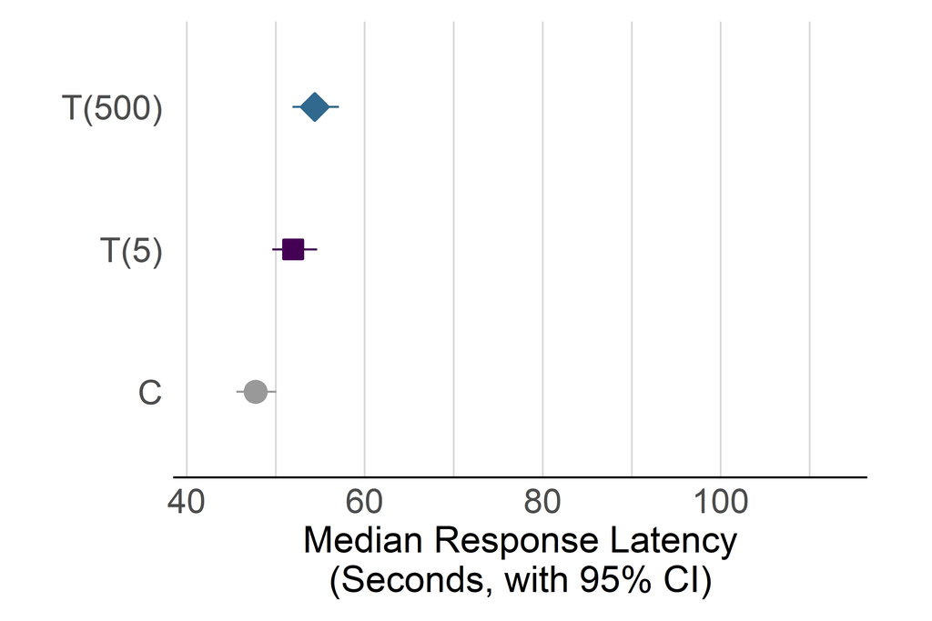

```r
time_median_federal <- compute_time_effects(m_time_full_federal_avg_case_sim, "median", time_diffs_federal) # helper

plot_time_median_federal <- plot_time_pred( # helper
  create_time_pred_data(time_median_federal$summary, "Cond. Median", election = "federal"), # helper
  stat = "Cond. Median", election = "federal",
  x_limits = x_limits_time_median, x_breaks = x_breaks_time_median
)
plot_time_median_federal
```

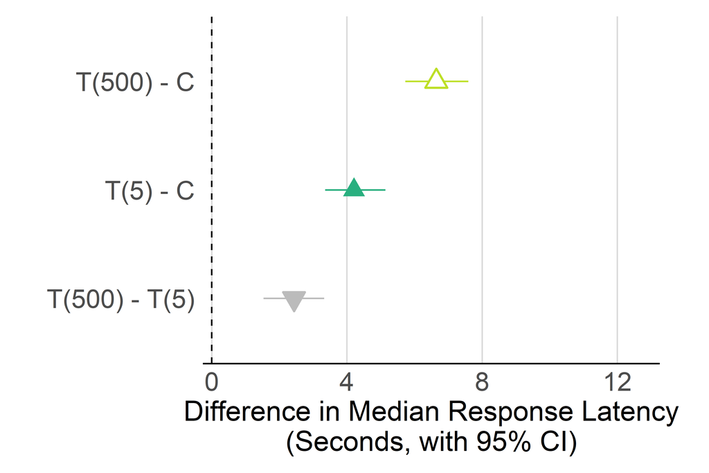

```r
save_figure(plot_time_median_federal, "figure_2a_h1_median_federal",
  election = "federal", # helper
  width = "subfigure", aspect = 1 / 2
)

plot_time_median_fd_federal <- plot_time_diff( # helper
  create_time_diff_data(time_median_federal$diff, "FD Median"), # helper
  stat = "FD Median", election = "federal",
  names_vec = names(time_diffs_federal),
  x_limits = x_limits_time_fd_median, x_breaks = x_breaks_time_fd_median
)
plot_time_median_fd_federal
```

```r
save_figure(plot_time_median_fd_federal, "figure_2b_h1_median_fd_federal",
  election = "federal", # helper
  width = "subfigure", aspect = 1 / 2
)
```

```r
create_time_pred_data(time_median_federal$summary, "Cond. Median", election = "federal") %>% print_values(digits = 1) # helper
```

```
  Group         Type Estimate Lower Upper
      C Cond. Median     47.7  45.6  50.1
   T(5) Cond. Median     52.0  49.6  54.7
 T(500) Cond. Median     54.4  51.9  57.1
```

```r
create_time_diff_data(time_median_federal$diff, "FD Median") %>% print_values(digits = 1) # helper
```

```
    Comparison      Type  FD Lower Upper
 T(500) - T(5) FD Median 2.4   1.5   3.3
      T(5) - C FD Median 4.2   3.4   5.1
    T(500) - C FD Median 6.6   5.7   7.6
```

## Figure C.1: Conditional Mean

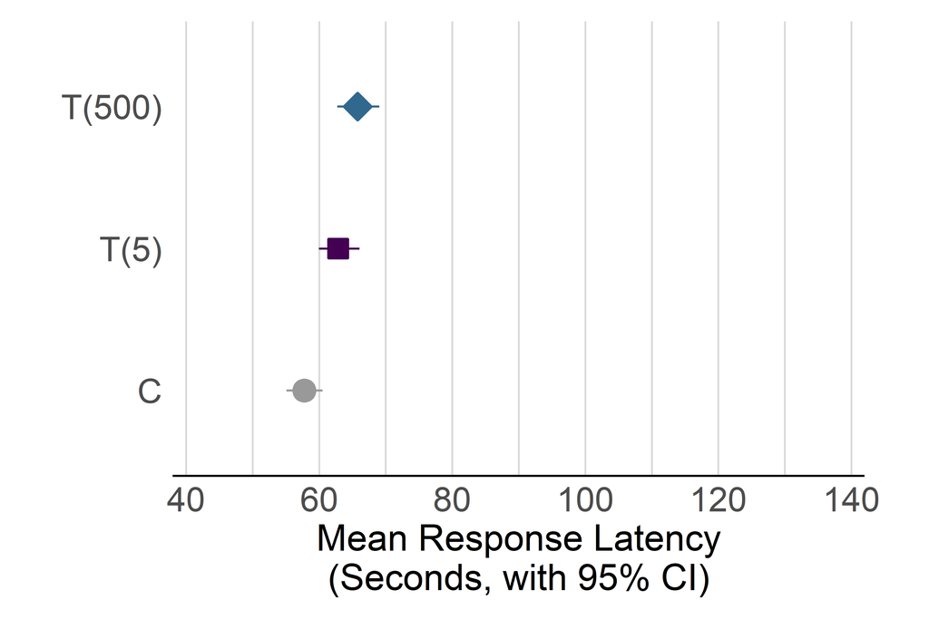

```r
time_mean_federal <- compute_time_effects(m_time_full_federal_avg_case_sim, "mean", time_diffs_federal) # helper

plot_time_mean_federal <- plot_time_pred( # helper
  create_time_pred_data(time_mean_federal$summary, "Cond. Mean", election = "federal"), # helper
  stat = "Cond. Mean", election = "federal",
  x_limits = x_limits_time_mean, x_breaks = x_breaks_time_mean
)
plot_time_mean_federal
```

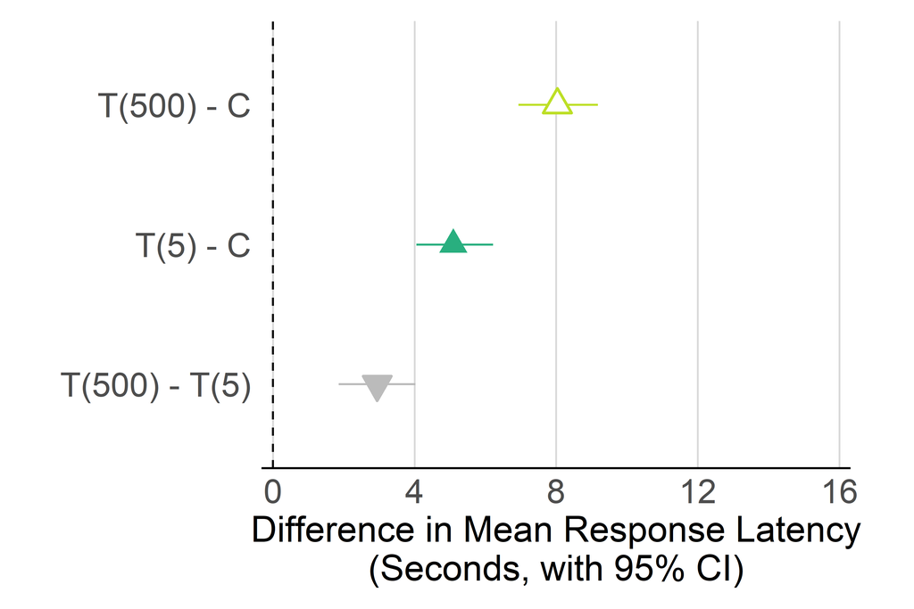

```r
save_figure(plot_time_mean_federal, "figure_C1a_h1_mean_federal",
  election = "federal", # helper
  width = "subfigure", aspect = 1 / 2
)

plot_time_mean_fd_federal <- plot_time_diff( # helper
  create_time_diff_data(time_mean_federal$diff, "FD Mean"), # helper
  stat = "FD Mean", election = "federal",
  names_vec = names(time_diffs_federal)
)
plot_time_mean_fd_federal
```

```r
save_figure(plot_time_mean_fd_federal, "figure_C1b_h1_mean_fd_federal",
  election = "federal", # helper
  width = "subfigure", aspect = 1 / 2
)
```

```r
create_time_pred_data(time_mean_federal$summary, "Cond. Mean", election = "federal") %>% print_values(digits = 1) # helper
```

```
  Group       Type Estimate Lower Upper
      C Cond. Mean     57.8  55.1  60.5
   T(5) Cond. Mean     62.9  60.0  66.1
 T(500) Cond. Mean     65.8  62.7  69.0
```

```r
create_time_diff_data(time_mean_federal$diff, "FD Mean") %>% print_values(digits = 1) # helper
```

```
    Comparison    Type  FD Lower Upper
 T(500) - T(5) FD Mean 2.9   1.9   4.0
      T(5) - C FD Mean 5.1   4.1   6.2
    T(500) - C FD Mean 8.0   6.9   9.2
```

# H2: Overall Accuracy

## Model 2a: MAE (Figure 3)

Individual MAE and RMSE (paper section Modeling and appendix section Plots Robustness Checks).

```r
data_federal_main %>%
  summarize(across(
    c(list_votes_exp_mae, list_votes_exp_rmse),
    list(min = min, mean = mean, sd = sd, max = max)
  )) %>%
  print_values(digits = 2) # helper
```

```
 list_votes_exp_mae_min list_votes_exp_mae_mean list_votes_exp_mae_sd list_votes_exp_mae_max list_votes_exp_rmse_min
                   0.43                    4.46                  2.91                  20.48                    0.48
 list_votes_exp_rmse_mean list_votes_exp_rmse_sd list_votes_exp_rmse_max
                     5.53                   3.63                   24.43
```

```r
m_mae_full_federal <- lm(list_votes_exp_mae ~ treatment + lead_time, data = data_federal_main)
summary(m_mae_full_federal)
```

```
Call:
lm(formula = list_votes_exp_mae ~ treatment + lead_time, data = data_federal_main)

Residuals:
   Min     1Q Median     3Q    Max
-4.635 -2.046 -0.878  1.214 16.056

Coefficients:
                         Estimate Std. Error t value Pr(>|t|)
(Intercept)                3.9272     0.3656   10.74  < 2e-16 ***
treatmentTreatment (5)    -0.2279     0.0422   -5.41  6.5e-08 ***
treatmentTreatment (500)  -0.3193     0.0421   -7.59  3.3e-14 ***
lead_time3                 1.1348     0.3741    3.03   0.0024 **
lead_time4                 0.8912     0.3680    2.42   0.0154 *
lead_time5                 0.5454     0.3691    1.48   0.1395
lead_time10               -0.6322     0.4424   -1.43   0.1530
lead_time11               -0.3836     0.3971   -0.97   0.3341
lead_time12               -0.2081     0.3931   -0.53   0.5966
lead_time13               -0.0836     0.3884   -0.22   0.8296
lead_time14                0.5939     0.3826    1.55   0.1207
lead_time15                0.5924     0.3815    1.55   0.1205
lead_time16                0.6643     0.3749    1.77   0.0764 .
lead_time17                0.7420     0.3708    2.00   0.0454 *
lead_time18                0.7992     0.3672    2.18   0.0295 *
lead_time19                0.6164     0.3674    1.68   0.0934 .
lead_time20                0.7539     0.3700    2.04   0.0416 *
lead_time21                0.9097     0.3911    2.33   0.0200 *
lead_time22                0.9056     0.3843    2.36   0.0184 *
lead_time23                1.0214     0.3714    2.75   0.0060 **
lead_time25                0.7694     0.3960    1.94   0.0520 .
lead_time26                0.8038     0.4319    1.86   0.0627 .
lead_time29                0.3819     0.4271    0.89   0.3713
lead_time30                0.6033     0.3994    1.51   0.1309
---
Signif. codes:  0 '***' 0.001 '**' 0.01 '*' 0.05 '.' 0.1 ' ' 1

Residual standard error: 2.9 on 28406 degrees of freedom
Multiple R-squared:  0.0106,    Adjusted R-squared:  0.00983
F-statistic: 13.3 on 23 and 28406 DF,  p-value: <2e-16
```

```r
mae_federal <- compute_treatment_effects(m_mae_full_federal, data_federal_main) # helper
```

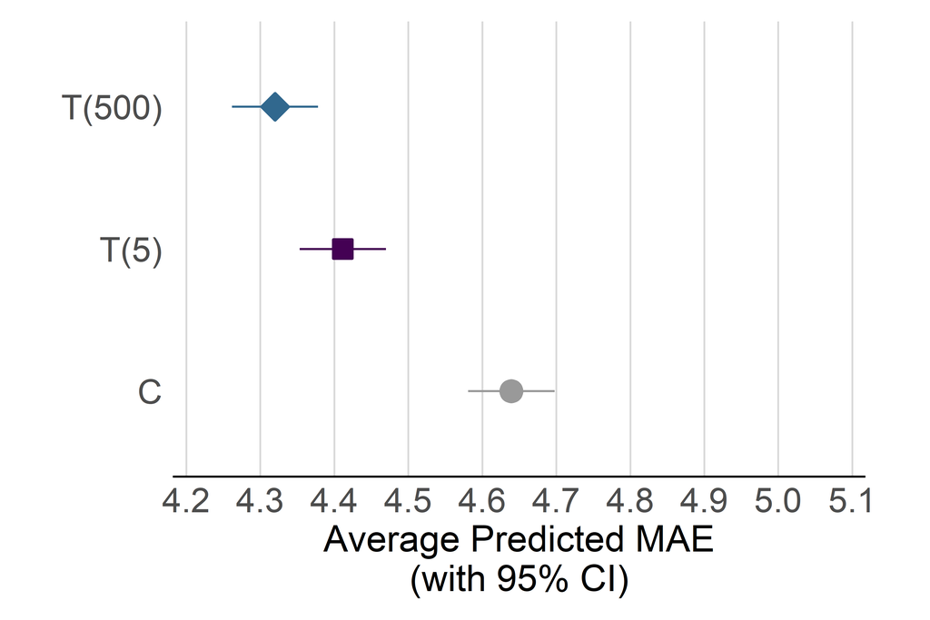

```r
plot_mae_federal <- plot_accuracy_pred(mae_federal$pred, "Average Predicted MAE\n(with 95% CI)", # helper
  y_limits = c(4.2, 5.1), y_breaks = seq(4.2, 5.1, by = 0.1),
  election = "federal"
)
plot_mae_federal
```

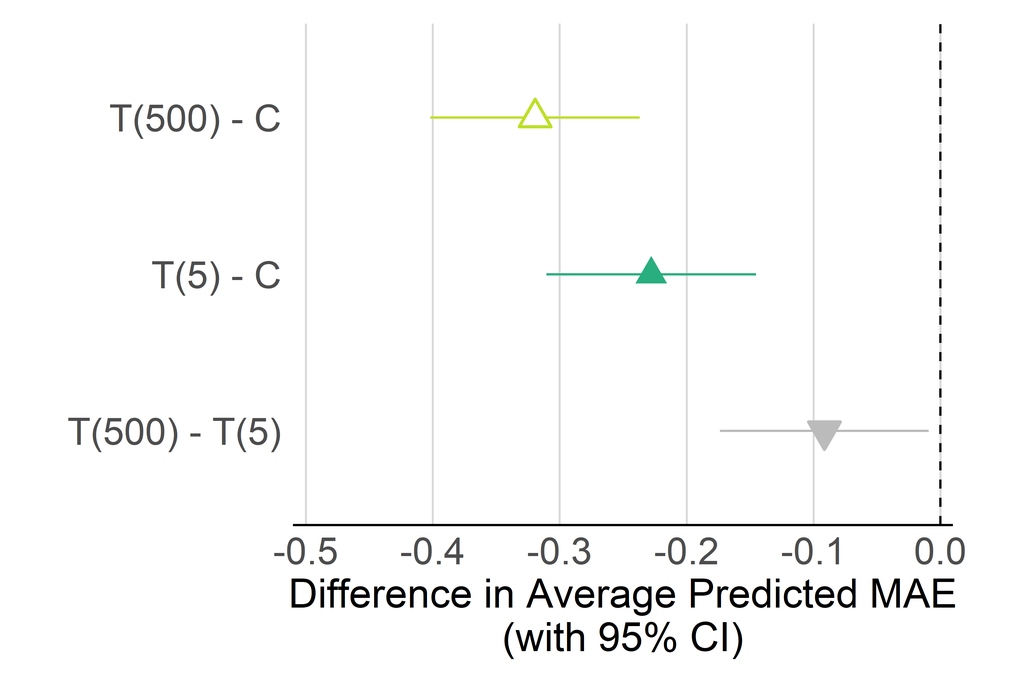

```r
save_figure(plot_mae_federal, "figure_3a_h2_mae_federal",
  election = "federal", # helper
  width = "subfigure", aspect = 1 / 2
)

plot_mae_fd_federal <- plot_accuracy_diff(mae_federal$diff, "Difference in Average Predicted MAE\n(with 95% CI)", # helper
  y_limits = c(-0.5, 0), y_breaks = seq(-0.5, 0, by = 0.1),
  election = "federal"
)
plot_mae_fd_federal
```

```r
save_figure(plot_mae_fd_federal, "figure_3b_h2_mae_fd_federal",
  election = "federal", # helper
  width = "subfigure", aspect = 1 / 2
)
```

```r
print_values(mae_federal$pred, c("treatment", est_cols)) # helper
```

```
       treatment estimate conf.low conf.high
         Control     4.64     4.58      4.70
   Treatment (5)     4.41     4.35      4.47
 Treatment (500)     4.32     4.26      4.38
```

```r
print_values(mae_federal$diff, c("diff", est_cols)) # helper
```

```
          diff estimate conf.low conf.high
      T(5) - C    -0.23    -0.31     -0.15
    T(500) - C    -0.32    -0.40     -0.24
 T(500) - T(5)    -0.09    -0.17     -0.01
```

## Model 2b: RMSE (Figure C.2)

```r
m_rmse_full_federal <- lm(list_votes_exp_rmse ~ treatment + lead_time, data = data_federal_main)
summary(m_rmse_full_federal)
```

```
Call:
lm(formula = list_votes_exp_rmse ~ treatment + lead_time, data = data_federal_main)

Residuals:
   Min     1Q Median     3Q    Max
 -5.79  -2.54  -1.14   1.44  19.23

Coefficients:
                         Estimate Std. Error t value Pr(>|t|)
(Intercept)                4.8818     0.4564   10.70  < 2e-16 ***
treatmentTreatment (5)    -0.2733     0.0526   -5.19  2.1e-07 ***
treatmentTreatment (500)  -0.3912     0.0525   -7.45  9.6e-14 ***
lead_time3                 1.3921     0.4670    2.98   0.0029 **
lead_time4                 1.0906     0.4593    2.37   0.0176 *
lead_time5                 0.6729     0.4608    1.46   0.1442
lead_time10               -0.7594     0.5522   -1.38   0.1691
lead_time11               -0.4665     0.4957   -0.94   0.3467
lead_time12               -0.2539     0.4907   -0.52   0.6049
lead_time13               -0.0900     0.4849   -0.19   0.8528
lead_time14                0.7130     0.4777    1.49   0.1355
lead_time15                0.7015     0.4762    1.47   0.1408
lead_time16                0.7807     0.4680    1.67   0.0953 .
lead_time17                0.9173     0.4629    1.98   0.0475 *
lead_time18                0.9707     0.4584    2.12   0.0342 *
lead_time19                0.7487     0.4587    1.63   0.1026
lead_time20                0.9132     0.4619    1.98   0.0480 *
lead_time21                1.0986     0.4883    2.25   0.0245 *
lead_time22                1.1171     0.4797    2.33   0.0199 *
lead_time23                1.2656     0.4637    2.73   0.0063 **
lead_time25                0.9217     0.4943    1.86   0.0622 .
lead_time26                0.9828     0.5391    1.82   0.0683 .
lead_time29                0.4910     0.5332    0.92   0.3571
lead_time30                0.7090     0.4986    1.42   0.1551
---
Signif. codes:  0 '***' 0.001 '**' 0.01 '*' 0.05 '.' 0.1 ' ' 1

Residual standard error: 3.61 on 28406 degrees of freedom
Multiple R-squared:  0.0102,    Adjusted R-squared:  0.00943
F-statistic: 12.8 on 23 and 28406 DF,  p-value: <2e-16
```

```r
rmse_federal <- compute_treatment_effects(m_rmse_full_federal, data_federal_main) # helper
```

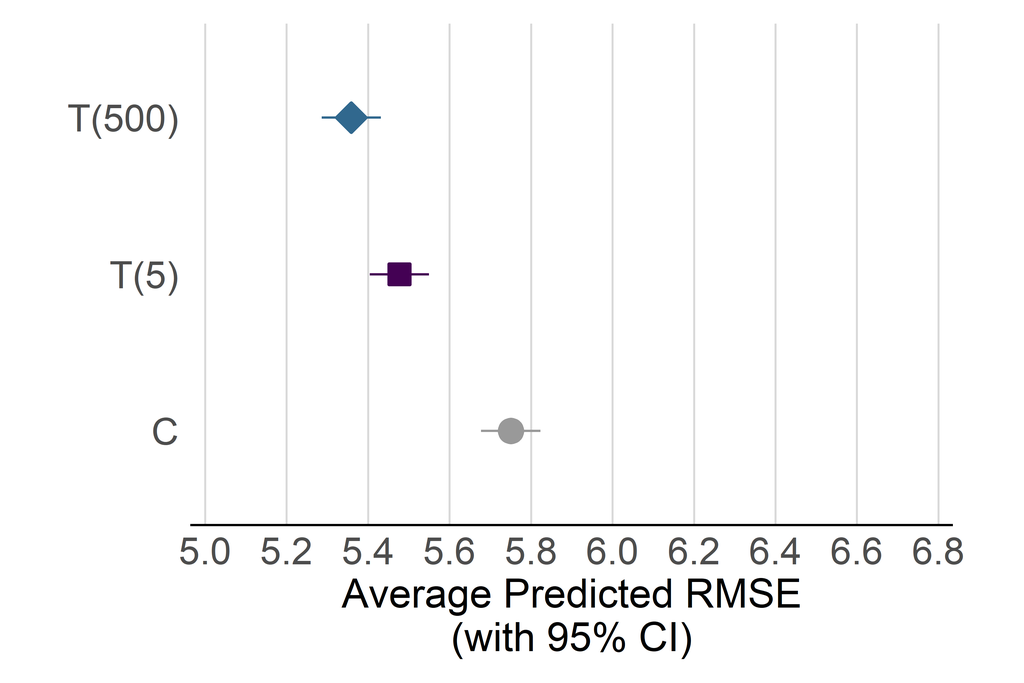

```r
plot_rmse_federal <- plot_accuracy_pred(rmse_federal$pred, "Average Predicted RMSE\n(with 95% CI)", # helper
  y_limits = c(5.0, 6.8), y_breaks = seq(5.0, 6.8, by = 0.2),
  election = "federal"
)
plot_rmse_federal
```

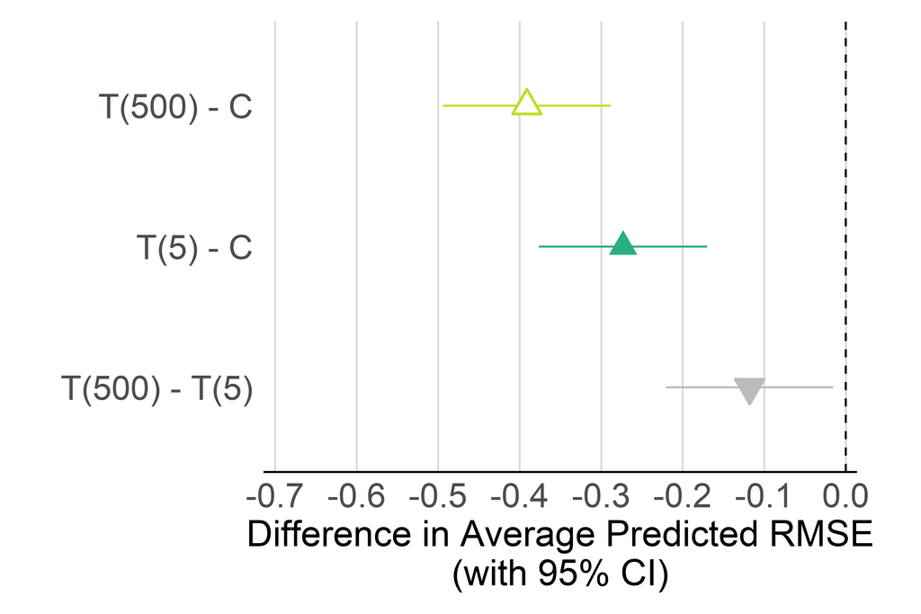

```r
save_figure(plot_rmse_federal, "figure_C2a_h2_rmse_federal",
  election = "federal", # helper
  width = "subfigure", aspect = 1 / 2
)

plot_rmse_fd_federal <- plot_accuracy_diff(rmse_federal$diff, "Difference in Average Predicted RMSE\n(with 95% CI)", # helper
  y_limits = c(-0.7, 0), y_breaks = seq(-0.7, 0, by = 0.1),
  election = "federal"
)
plot_rmse_fd_federal
```

```r
save_figure(plot_rmse_fd_federal, "figure_C2b_h2_rmse_fd_federal",
  election = "federal", # helper
  width = "subfigure", aspect = 1 / 2
)
```

```r
print_values(rmse_federal$pred, c("treatment", est_cols)) # helper
```

```
       treatment estimate conf.low conf.high
         Control     5.75     5.68      5.82
   Treatment (5)     5.48     5.40      5.55
 Treatment (500)     5.36     5.29      5.43
```

```r
print_values(rmse_federal$diff, c("diff", est_cols)) # helper
```

```
          diff estimate conf.low conf.high
      T(5) - C    -0.27    -0.38     -0.17
    T(500) - C    -0.39    -0.49     -0.29
 T(500) - T(5)    -0.12    -0.22     -0.02
```

## Heterogeneity by Education (Figure C.9)

MAE on treatment interacted with educational attainment.

```r
data_federal_educ_main <- data_federal_main %>%
  filter(!is.na(education_eng), education_eng != "Still in School") %>%
  mutate(education_eng = droplevels(factor(education_eng, levels = c("High", "Medium", "Low"))))

m_mae_educ_federal <- lm(list_votes_exp_mae ~ treatment * education_eng + lead_time,
  data = data_federal_educ_main
)
summary(m_mae_educ_federal)
```

```
Call:
lm(formula = list_votes_exp_mae ~ treatment * education_eng +
    lead_time, data = data_federal_educ_main)

Residuals:
   Min     1Q Median     3Q    Max
-5.327 -1.961 -0.824  1.181 16.449

Coefficients:
                                             Estimate Std. Error t value Pr(>|t|)
(Intercept)                                   3.39359    0.36001    9.43  < 2e-16 ***
treatmentTreatment (5)                       -0.18157    0.05679   -3.20   0.0014 **
treatmentTreatment (500)                     -0.31481    0.05694   -5.53  3.3e-08 ***
education_engMedium                           0.69881    0.06371   10.97  < 2e-16 ***
education_engLow                              1.62199    0.10018   16.19  < 2e-16 ***
lead_time3                                    1.16927    0.36735    3.18   0.0015 **
lead_time4                                    0.96687    0.36113    2.68   0.0074 **
lead_time5                                    0.63613    0.36229    1.76   0.0791 .
lead_time10                                  -0.49211    0.43461   -1.13   0.2575
lead_time11                                  -0.28488    0.38982   -0.73   0.4649
lead_time12                                  -0.08551    0.38624   -0.22   0.8248
lead_time13                                  -0.03503    0.38140   -0.09   0.9268
lead_time14                                   0.71504    0.37575    1.90   0.0571 .
lead_time15                                   0.70637    0.37465    1.89   0.0594 .
lead_time16                                   0.77246    0.36800    2.10   0.0358 *
lead_time17                                   0.85903    0.36395    2.36   0.0183 *
lead_time18                                   0.91807    0.36038    2.55   0.0109 *
lead_time19                                   0.75121    0.36056    2.08   0.0372 *
lead_time20                                   0.87634    0.36312    2.41   0.0158 *
lead_time21                                   1.04323    0.38407    2.72   0.0066 **
lead_time22                                   1.03170    0.37737    2.73   0.0063 **
lead_time23                                   1.17144    0.36458    3.21   0.0013 **
lead_time25                                   0.84262    0.38890    2.17   0.0303 *
lead_time26                                   0.92507    0.42456    2.18   0.0293 *
lead_time29                                   0.37099    0.41976    0.88   0.3768
lead_time30                                   0.63185    0.39240    1.61   0.1074
treatmentTreatment (5):education_engMedium   -0.13537    0.09002   -1.50   0.1327
treatmentTreatment (500):education_engMedium -0.08122    0.08978   -0.90   0.3657
treatmentTreatment (5):education_engLow       0.00287    0.14149    0.02   0.9838
treatmentTreatment (500):education_engLow     0.02017    0.13972    0.14   0.8852
---
Signif. codes:  0 '***' 0.001 '**' 0.01 '*' 0.05 '.' 0.1 ' ' 1

Residual standard error: 2.84 on 27922 degrees of freedom
Multiple R-squared:  0.0421,    Adjusted R-squared:  0.0411
F-statistic: 42.3 on 29 and 27922 DF,  p-value: <2e-16
```

```r
count_model_n(m_mae_educ_federal, data_federal_educ_main) # helper
```

```
# A tibble: 1 × 2
  respondents observations
        <int>        <int>
1       27952        27952
```

```r
mae_educ_federal <- compute_treatment_effects(m_mae_educ_federal, data_federal_educ_main, by = "education_eng") # helper
mae_educ_federal$pred <- mae_educ_federal$pred %>%
  mutate(treatment = factor_groups_federal(treatment)) # helper
mae_educ_federal$diff <- mae_educ_federal$diff %>%
  mutate(education_eng = factor(education_eng, levels = c("High", "Medium", "Low")))
```

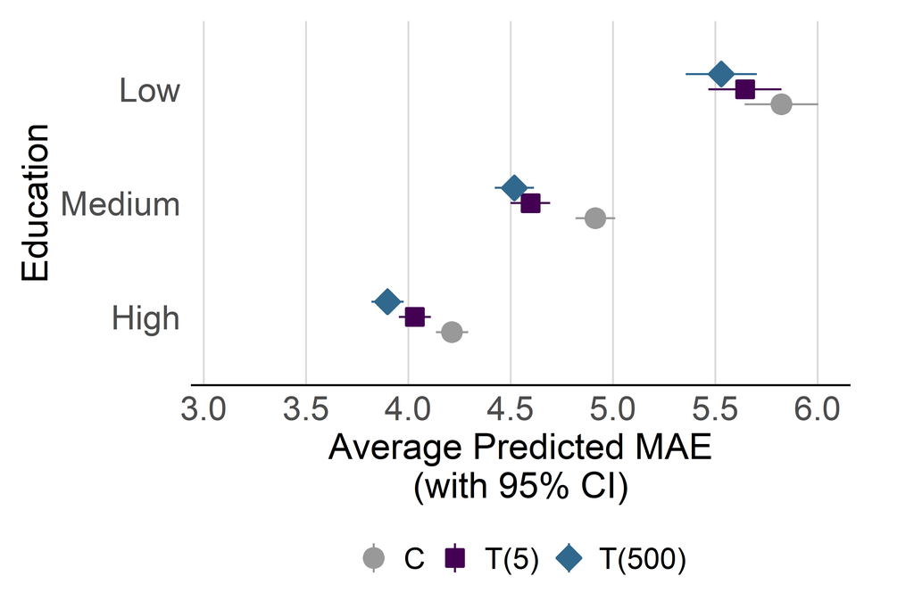

```r
plot_mae_educ_federal <- plot_by_moderator( # helper
  mae_educ_federal$pred, "education_eng", "Education", "Average Predicted MAE\n(with 95% CI)",
  election = "federal", y_limits = c(3, 6.1), y_breaks = seq(3, 6.5, by = 0.5)
)
plot_mae_educ_federal
```

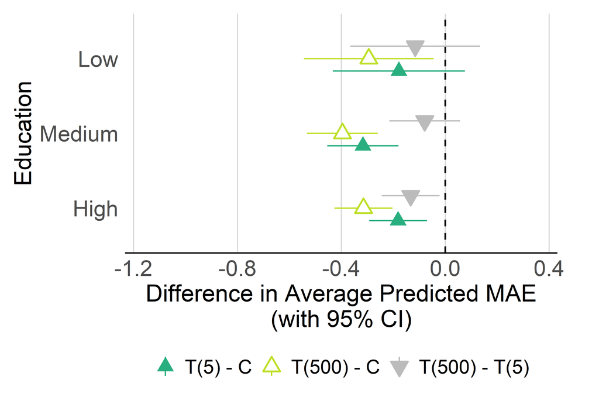

```r
save_figure(plot_mae_educ_federal, "figure_C9a_h2_mae_educ_federal",
  election = "federal", # helper
  width = "subfigure", aspect = 5 / 8
)

plot_mae_educ_fd_federal <- plot_by_moderator( # helper
  mae_educ_federal$diff, "education_eng", "Education", "Difference in Average Predicted MAE\n(with 95% CI)",
  election = "federal", diff = TRUE, y_limits = c(-1.2, 0.4), y_breaks = round(seq(-1.2, 0.4, by = 0.4), 1)
)
plot_mae_educ_fd_federal
```

```r
save_figure(plot_mae_educ_fd_federal, "figure_C9b_h2_mae_educ_fd_federal",
  election = "federal", # helper
  width = "subfigure", aspect = 5 / 8
)
```

```r
print_values(mae_educ_federal$diff, c("education_eng", "diff", est_cols)) # helper
```

```
 education_eng          diff estimate conf.low conf.high
          High      T(5) - C    -0.18    -0.29     -0.07
          High    T(500) - C    -0.31    -0.43     -0.20
          High T(500) - T(5)    -0.13    -0.24     -0.02
        Medium      T(5) - C    -0.32    -0.45     -0.18
        Medium    T(500) - C    -0.40    -0.53     -0.26
        Medium T(500) - T(5)    -0.08    -0.22      0.06
           Low      T(5) - C    -0.18    -0.43      0.08
           Low    T(500) - C    -0.29    -0.54     -0.04
           Low T(500) - T(5)    -0.12    -0.37      0.13
```

## Heterogeneity by Political Interest (Figure C.10)

```r
pol_interest_levels_federal <- c("Sehr stark", "Stark", "Mittelmäßig", "Weniger stark", "Überhaupt nicht")

data_federal_polint_main <- data_federal_main %>%
  filter(!is.na(pol_interest)) %>%
  mutate(pol_interest = recode_pol_interest(pol_interest, pol_interest_levels_federal)) # helper

m_mae_polint_federal <- lm(list_votes_exp_mae ~ treatment * pol_interest + lead_time,
  data = data_federal_polint_main
)
summary(m_mae_polint_federal)
```

```
Call:
lm(formula = list_votes_exp_mae ~ treatment * pol_interest +
    lead_time, data = data_federal_polint_main)

Residuals:
   Min     1Q Median     3Q    Max
-5.056 -1.915 -0.879  1.076 16.118

Coefficients:
                                                Estimate Std. Error t value Pr(>|t|)
(Intercept)                                       3.6327     0.3631   10.01   <2e-16 ***
treatmentTreatment (5)                           -0.3009     0.0996   -3.02   0.0025 **
treatmentTreatment (500)                         -0.3104     0.0992   -3.13   0.0018 **
pol_interestStrongly                              0.0614     0.0873    0.70   0.4818
pol_interestModerately                            0.7710     0.0862    8.95   <2e-16 ***
pol_interestNot very                              1.4757     0.1148   12.86   <2e-16 ***
pol_interestNot at all                            2.2879     0.1633   14.01   <2e-16 ***
lead_time3                                        0.8486     0.3664    2.32   0.0206 *
lead_time4                                        0.6375     0.3603    1.77   0.0769 .
lead_time5                                        0.3862     0.3614    1.07   0.2853
lead_time10                                      -0.7223     0.4331   -1.67   0.0953 .
lead_time11                                      -0.4879     0.3889   -1.25   0.2097
lead_time12                                      -0.3187     0.3848   -0.83   0.4075
lead_time13                                      -0.2305     0.3803   -0.61   0.5444
lead_time14                                       0.2380     0.3748    0.63   0.5255
lead_time15                                       0.2815     0.3736    0.75   0.4512
lead_time16                                       0.3339     0.3672    0.91   0.3631
lead_time17                                       0.4143     0.3632    1.14   0.2539
lead_time18                                       0.5048     0.3596    1.40   0.1604
lead_time19                                       0.4008     0.3598    1.11   0.2653
lead_time20                                       0.5122     0.3623    1.41   0.1575
lead_time21                                       0.6005     0.3831    1.57   0.1170
lead_time22                                       0.6469     0.3763    1.72   0.0856 .
lead_time23                                       0.8044     0.3637    2.21   0.0270 *
lead_time25                                       0.4909     0.3877    1.27   0.2055
lead_time26                                       0.5378     0.4229    1.27   0.2035
lead_time29                                       0.2271     0.4182    0.54   0.5870
lead_time30                                       0.3605     0.3911    0.92   0.3567
treatmentTreatment (5):pol_interestStrongly       0.0705     0.1228    0.57   0.5662
treatmentTreatment (500):pol_interestStrongly     0.0704     0.1225    0.57   0.5655
treatmentTreatment (5):pol_interestModerately     0.1607     0.1214    1.32   0.1855
treatmentTreatment (500):pol_interestModerately  -0.0236     0.1209   -0.19   0.8454
treatmentTreatment (5):pol_interestNot very       0.0411     0.1624    0.25   0.8002
treatmentTreatment (500):pol_interestNot very    -0.0770     0.1617   -0.48   0.6338
treatmentTreatment (5):pol_interestNot at all    -0.0172     0.2310   -0.07   0.9407
treatmentTreatment (500):pol_interestNot at all  -0.1330     0.2329   -0.57   0.5679
---
Signif. codes:  0 '***' 0.001 '**' 0.01 '*' 0.05 '.' 0.1 ' ' 1

Residual standard error: 2.83 on 28377 degrees of freedom
Multiple R-squared:  0.0504,    Adjusted R-squared:  0.0493
F-statistic: 43.1 on 35 and 28377 DF,  p-value: <2e-16
```

```r
count_model_n(m_mae_polint_federal, data_federal_polint_main) # helper
```

```
# A tibble: 1 × 2
  respondents observations
        <int>        <int>
1       28413        28413
```

```r
mae_polint_federal <- compute_treatment_effects(m_mae_polint_federal, data_federal_polint_main, by = "pol_interest") # helper
mae_polint_federal$pred <- mae_polint_federal$pred %>%
  mutate(treatment = factor_groups_federal(treatment)) # helper
mae_polint_federal$diff <- mae_polint_federal$diff %>%
  mutate(pol_interest = factor(pol_interest, levels = levels(data_federal_polint_main$pol_interest)))
```

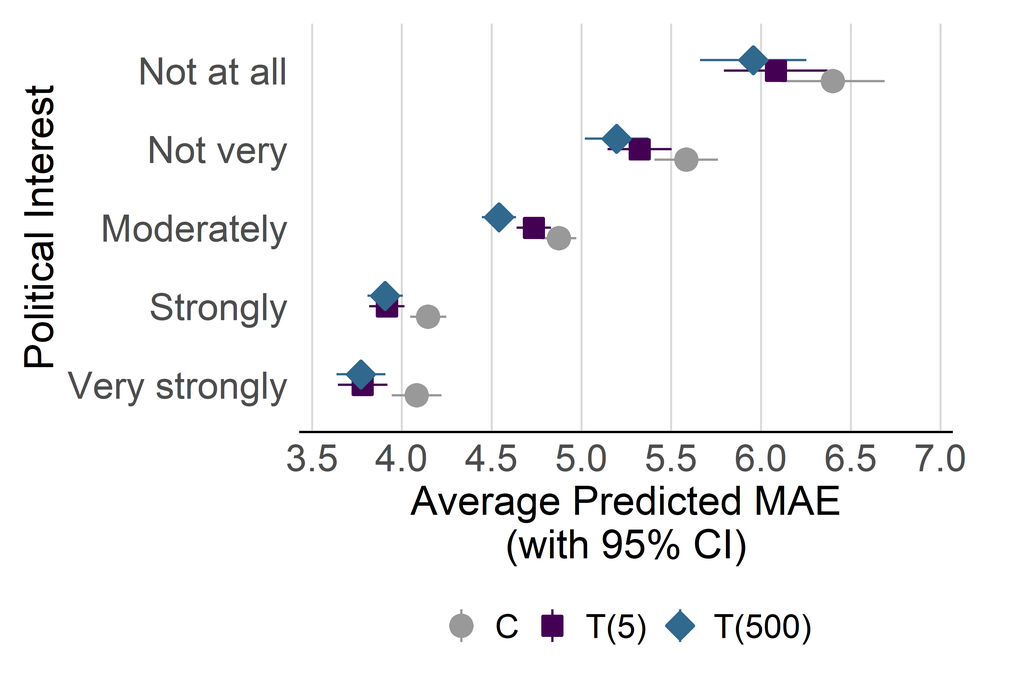

```r
plot_mae_polint_federal <- plot_by_moderator( # helper
  mae_polint_federal$pred, "pol_interest", "Political Interest", "Average Predicted MAE\n(with 95% CI)",
  election = "federal"
)
plot_mae_polint_federal
```

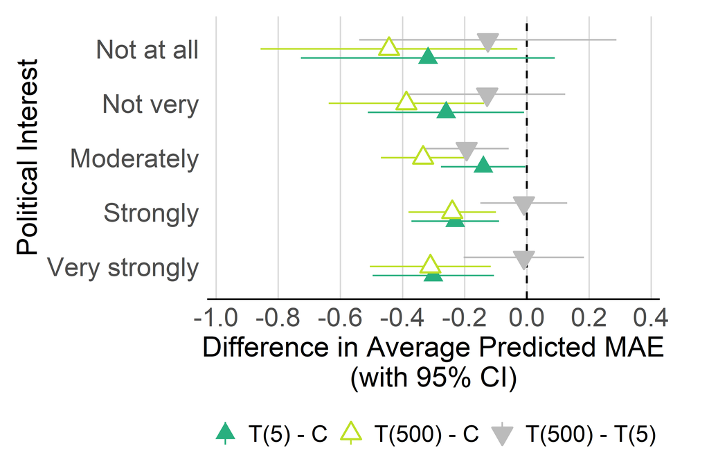

```r
save_figure(plot_mae_polint_federal, "figure_C10a_h2_mae_polint_federal",
  election = "federal", # helper
  width = "subfigure", aspect = 5 / 8
)

plot_mae_polint_fd_federal <- plot_by_moderator( # helper
  mae_polint_federal$diff, "pol_interest", "Political Interest", "Difference in Average Predicted MAE\n(with 95% CI)",
  election = "federal", diff = TRUE
)
plot_mae_polint_fd_federal
```

```r
save_figure(plot_mae_polint_fd_federal, "figure_C10b_h2_mae_polint_fd_federal",
  election = "federal", # helper
  width = "subfigure", aspect = 5 / 8
)
```

# H3: Wishful Thinking

## Wishful Thinking by Party (Figures 4 and B.7)

One model per party: forecast error on whether the party is the respondent’s preferred party (highest PTV).

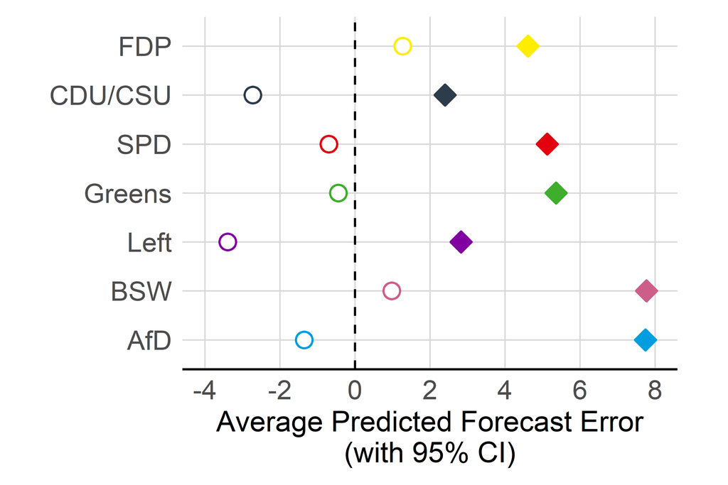

```r
wt_byparty_ptv_federal <- fit_wt_by_party(data_federal_ptv_main, "preferred_party_ptv_dummy", # helper
  parties_7_federal,
  election = "federal"
)

plot_wt_byparty_federal <- plot_wt_by_party_pred(wt_byparty_ptv_federal$pred, election = "federal") # helper
plot_wt_byparty_federal
```

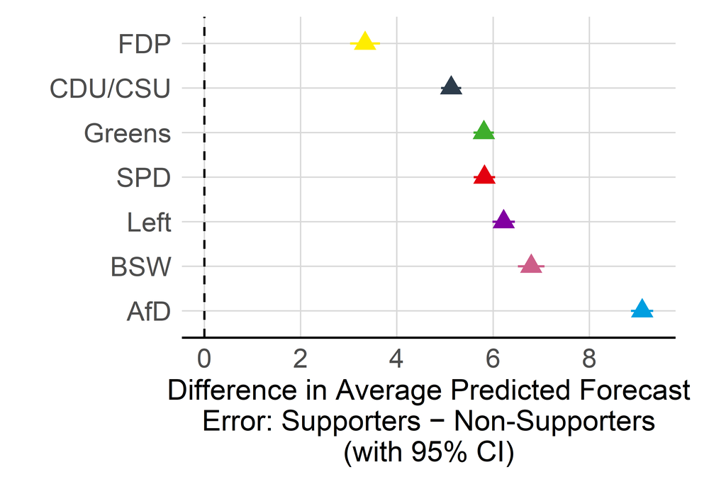

```r
save_figure(plot_wt_byparty_federal, "figure_B7a_h3_wt_byparty_federal",
  election = "federal", # helper
  width = "subfigure", aspect = 6 / 8
)

plot_wt_byparty_fd_federal <- plot_wt_by_party_diff(wt_byparty_ptv_federal$diff, election = "federal") # helper
plot_wt_byparty_fd_federal
```

```r
save_figure(plot_wt_byparty_fd_federal, "figure_4a_h3_wt_byparty_fd_federal",
  election = "federal", # helper
  width = "subfigure", aspect = 6 / 8
)
```

```r
print_values(wt_byparty_ptv_federal$pred, c("party", "preferred_party_dummy", est_cols)) # helper
```

```
   party preferred_party_dummy estimate conf.low conf.high
     AfD                    no    -1.35    -1.47     -1.24
     AfD                   yes     7.74     7.54      7.95
     BSW                    no     0.98     0.91      1.05
     BSW                   yes     7.77     7.50      8.04
 CDU/CSU                    no    -2.72    -2.84     -2.61
 CDU/CSU                   yes     2.41     2.23      2.58
     FDP                    no     1.27     1.21      1.33
     FDP                   yes     4.61     4.31      4.92
  Greens                    no    -0.44    -0.52     -0.36
  Greens                   yes     5.36     5.17      5.56
    Left                    no    -3.39    -3.46     -3.32
    Left                   yes     2.83     2.61      3.06
     SPD                    no    -0.70    -0.79     -0.61
     SPD                   yes     5.13     4.92      5.33
```

```r
print_values(wt_byparty_ptv_federal$diff, c("party", "diff", est_cols), digits = 1) # helper
```

```
   party     diff estimate conf.low conf.high
     AfD yes - no      9.1      8.9       9.3
     BSW yes - no      6.8      6.5       7.1
 CDU/CSU yes - no      5.1      4.9       5.3
     FDP yes - no      3.3      3.0       3.7
  Greens yes - no      5.8      5.6       6.0
    Left yes - no      6.2      6.0       6.5
     SPD yes - no      5.8      5.6       6.0
```

## Model 3a: Preferred Party by PTV Dummy (Figure 5)

Forecast error on treatment interacted with the preferred-party dummy, with survey date and party fixed effects. Standard errors are clustered by respondent.

```r
m_pref_ptv_federal <- lm(list_votes_exp_diff ~ treatment * preferred_party_ptv_dummy + lead_time + party,
  data = data_federal_ptv_main
)
lmtest::coeftest(m_pref_ptv_federal, vcov = sandwich::vcovCL(m_pref_ptv_federal, cluster = ~ResponseId))
```

```
t test of coefficients:

                                                   Estimate Std. Error t value Pr(>|t|)
(Intercept)                                         -0.6812     0.0861   -7.91  2.6e-15 ***
treatmentTreatment (5)                               0.0699     0.0250    2.79  0.00527 **
treatmentTreatment (500)                             0.0875     0.0249    3.51  0.00045 ***
preferred_party_ptv_dummy                            6.6196     0.1161   57.02  < 2e-16 ***
lead_time3                                          -0.0738     0.0722   -1.02  0.30701
lead_time4                                          -0.0341     0.0683   -0.50  0.61707
lead_time5                                          -0.0471     0.0688   -0.68  0.49389
lead_time10                                         -0.0395     0.0808   -0.49  0.62505
lead_time11                                         -0.1767     0.0790   -2.24  0.02540 *
lead_time12                                         -0.0685     0.0772   -0.89  0.37486
lead_time13                                         -0.0924     0.0746   -1.24  0.21520
lead_time14                                         -0.1519     0.0759   -2.00  0.04521 *
lead_time15                                         -0.0715     0.0739   -0.97  0.33307
lead_time16                                         -0.0972     0.0715   -1.36  0.17384
lead_time17                                         -0.1058     0.0697   -1.52  0.12884
lead_time18                                         -0.0987     0.0681   -1.45  0.14733
lead_time19                                         -0.0823     0.0681   -1.21  0.22638
lead_time20                                         -0.1081     0.0690   -1.57  0.11741
lead_time21                                         -0.1670     0.0811   -2.06  0.03957 *
lead_time22                                         -0.1653     0.0770   -2.15  0.03172 *
lead_time23                                         -0.1111     0.0701   -1.59  0.11287
lead_time25                                         -0.1312     0.0810   -1.62  0.10532
lead_time26                                         -0.2618     0.1075   -2.43  0.01494 *
lead_time29                                         -0.1124     0.0843   -1.33  0.18236
lead_time30                                         -0.0628     0.0845   -0.74  0.45735
partyBSW                                             1.7243     0.0652   26.43  < 2e-16 ***
partyCDU/CSU                                        -2.3507     0.0729  -32.27  < 2e-16 ***
partyFDP                                             1.8698     0.0672   27.81  < 2e-16 ***
partyGreens                                          0.1920     0.0712    2.70  0.00704 **
partyLeft                                           -2.6860     0.0687  -39.07  < 2e-16 ***
partySPD                                            -0.0707     0.0763   -0.93  0.35458
treatmentTreatment (5):preferred_party_ptv_dummy    -0.3198     0.1549   -2.06  0.03898 *
treatmentTreatment (500):preferred_party_ptv_dummy  -0.4190     0.1543   -2.71  0.00663 **
---
Signif. codes:  0 '***' 0.001 '**' 0.01 '*' 0.05 '.' 0.1 ' ' 1
```

```r
count_model_n(m_pref_ptv_federal, data_federal_ptv_main) # helper
```

```
# A tibble: 1 × 2
  respondents observations
        <int>        <int>
1       23056       160290
```

```r
ptv_federal <- compute_treatment_effects(m_pref_ptv_federal, data_federal_ptv_main, # helper
  by = "preferred_party_ptv_dummy", vcov = ~ResponseId
)
```

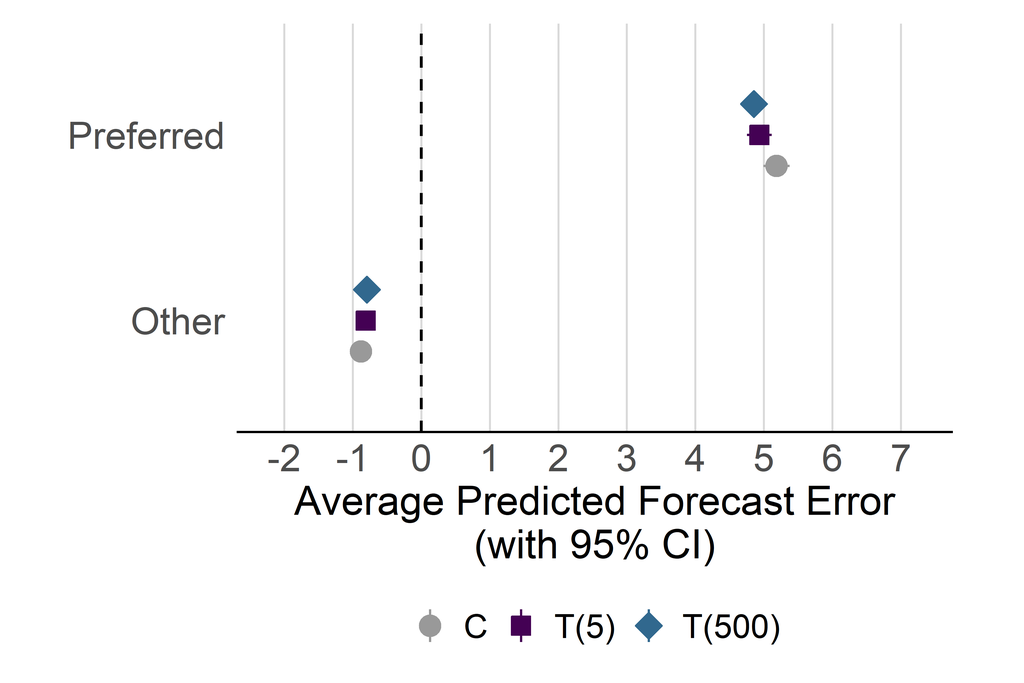

```r
plot_pref_ptv_federal <- plot_wishful_thinking_pred(ptv_federal$pred, "preferred_party_ptv_dummy", # helper
  election = "federal"
)
plot_pref_ptv_federal
```

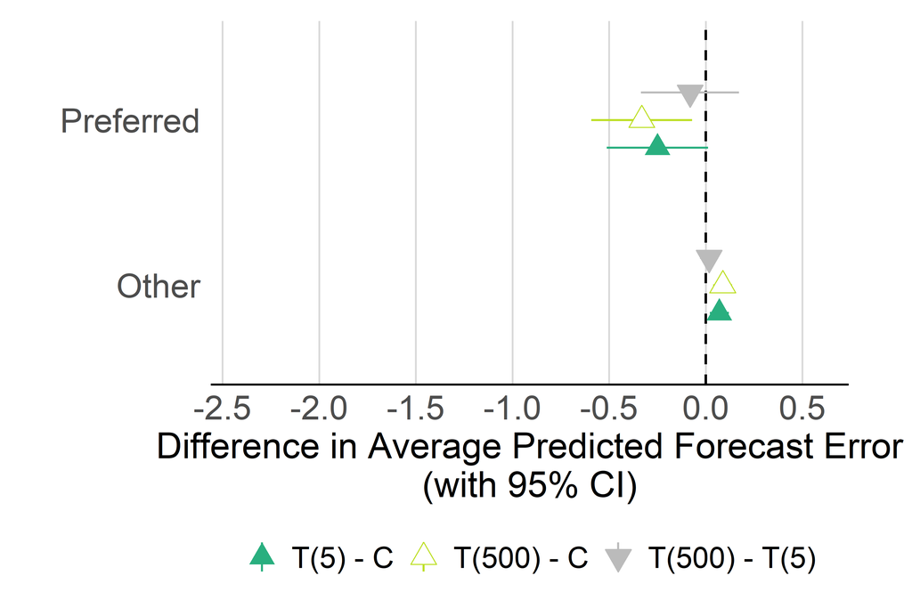

```r
save_figure(plot_pref_ptv_federal, "figure_5a_h3_ptv_federal",
  election = "federal", # helper
  width = "subfigure", aspect = 1 / 2
)

plot_pref_ptv_fd_federal <- plot_wishful_thinking_diff(ptv_federal$diff, "preferred_party_ptv_dummy", # helper
  election = "federal",
  y_limits = c(-2.5, 0.5),
  y_breaks = seq(-2.5, 0.5, by = 0.5)
)
plot_pref_ptv_fd_federal
```

```r
save_figure(plot_pref_ptv_fd_federal, "figure_5b_h3_ptv_fd_federal",
  election = "federal", # helper
  width = "subfigure", aspect = 1 / 2
)
```

```r
print_values(ptv_federal$pred, c("treatment", "preferred_party_ptv_dummy", est_cols)) # helper
```

```
       treatment preferred_party_ptv_dummy estimate conf.low conf.high
         Control                         0    -0.88    -0.91     -0.84
         Control                         1     5.19     5.00      5.38
   Treatment (5)                         0    -0.81    -0.84     -0.78
   Treatment (5)                         1     4.94     4.76      5.12
 Treatment (500)                         0    -0.79    -0.82     -0.76
 Treatment (500)                         1     4.85     4.68      5.03
```

```r
print_values(ptv_federal$diff, c("diff", "preferred_party_ptv_dummy", est_cols)) # helper
```

```
          diff preferred_party_ptv_dummy estimate conf.low conf.high
      T(5) - C                         0     0.07     0.02      0.12
    T(500) - C                         0     0.09     0.04      0.14
 T(500) - T(5)                         0     0.02    -0.03      0.06
      T(5) - C                         1    -0.25    -0.51      0.01
    T(500) - C                         1    -0.33    -0.59     -0.07
 T(500) - T(5)                         1    -0.08    -0.34      0.17
```

## Model 3b: PTV Dummy Including Ties (Figure C.3)

All parties sharing the highest PTV count as preferred.

```r
m_pref_ptv_ties_federal <- lm(list_votes_exp_diff ~ treatment * preferred_party_ptv_dummy_ties + lead_time + party,
  data = data_federal_ptvties_main
)
lmtest::coeftest(m_pref_ptv_ties_federal, vcov = sandwich::vcovCL(m_pref_ptv_ties_federal, cluster = ~ResponseId))
```

```
t test of coefficients:

                                                        Estimate Std. Error t value Pr(>|t|)
(Intercept)                                              -0.6368     0.1076   -5.92  3.2e-09 ***
treatmentTreatment (5)                                    0.0715     0.0249    2.87  0.00407 **
treatmentTreatment (500)                                  0.0930     0.0249    3.74  0.00018 ***
preferred_party_ptv_dummy_ties                            5.2362     0.0984   53.20  < 2e-16 ***
lead_time3                                               -0.1014     0.1000   -1.01  0.31066
lead_time4                                               -0.0886     0.0966   -0.92  0.35902
lead_time5                                               -0.0795     0.0968   -0.82  0.41150
lead_time10                                              -0.0831     0.1245   -0.67  0.50450
lead_time11                                              -0.2175     0.1084   -2.01  0.04477 *
lead_time12                                              -0.1100     0.1061   -1.04  0.29978
lead_time13                                              -0.1514     0.1039   -1.46  0.14494
lead_time14                                              -0.2091     0.1038   -2.02  0.04387 *
lead_time15                                              -0.1220     0.1023   -1.19  0.23305
lead_time16                                              -0.1329     0.0994   -1.34  0.18148
lead_time17                                              -0.1530     0.0980   -1.56  0.11854
lead_time18                                              -0.1564     0.0963   -1.62  0.10431
lead_time19                                              -0.1191     0.0962   -1.24  0.21574
lead_time20                                              -0.1460     0.0975   -1.50  0.13408
lead_time21                                              -0.2622     0.1127   -2.33  0.02003 *
lead_time22                                              -0.2489     0.1086   -2.29  0.02197 *
lead_time23                                              -0.1634     0.0986   -1.66  0.09734 .
lead_time25                                              -0.1316     0.1087   -1.21  0.22578
lead_time26                                              -0.3212     0.1419   -2.26  0.02358 *
lead_time29                                              -0.2818     0.1382   -2.04  0.04143 *
lead_time30                                              -0.1207     0.1118   -1.08  0.28032
partyBSW                                                  1.6260     0.0595   27.31  < 2e-16 ***
partyCDU/CSU                                             -2.5067     0.0670  -37.39  < 2e-16 ***
partyFDP                                                  1.8119     0.0616   29.42  < 2e-16 ***
partyGreens                                               0.1502     0.0658    2.28  0.02236 *
partyLeft                                                -2.7375     0.0628  -43.58  < 2e-16 ***
partySPD                                                 -0.0969     0.0705   -1.37  0.16929
treatmentTreatment (5):preferred_party_ptv_dummy_ties    -0.2638     0.1316   -2.00  0.04507 *
treatmentTreatment (500):preferred_party_ptv_dummy_ties  -0.2622     0.1315   -1.99  0.04617 *
---
Signif. codes:  0 '***' 0.001 '**' 0.01 '*' 0.05 '.' 0.1 ' ' 1
```

```r
count_model_n(m_pref_ptv_ties_federal, data_federal_ptvties_main) # helper
```

```
# A tibble: 1 × 2
  respondents observations
        <int>        <int>
1       28410       198870
```

```r
ptv_ties_federal <- compute_treatment_effects(m_pref_ptv_ties_federal, data_federal_ptvties_main, # helper
  by = "preferred_party_ptv_dummy_ties", vcov = ~ResponseId
)
```

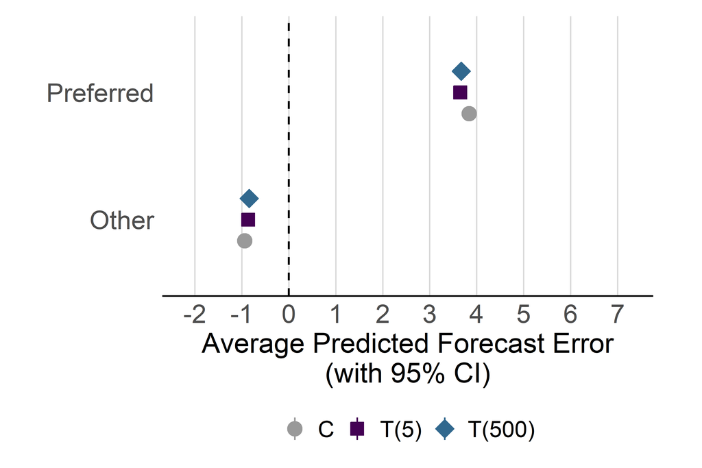

```r
plot_pref_ptv_ties_federal <- plot_wishful_thinking_pred(ptv_ties_federal$pred, "preferred_party_ptv_dummy_ties", # helper
  election = "federal"
)
plot_pref_ptv_ties_federal
```

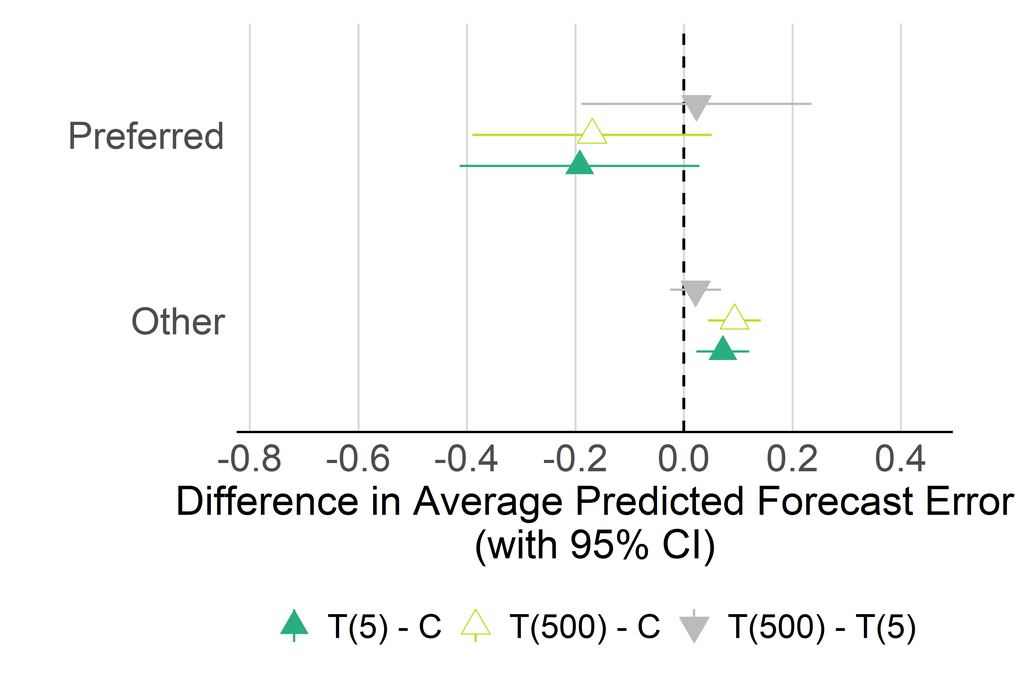

```r
save_figure(plot_pref_ptv_ties_federal, "figure_C3a_h3_ptv_ties_federal",
  election = "federal", # helper
  width = "subfigure", aspect = 1 / 2
)

plot_pref_ptv_ties_fd_federal <- plot_wishful_thinking_diff(ptv_ties_federal$diff, "preferred_party_ptv_dummy_ties", # helper
  election = "federal"
)
plot_pref_ptv_ties_fd_federal
```

```r
save_figure(plot_pref_ptv_ties_fd_federal, "figure_C3b_h3_ptv_ties_fd_federal",
  election = "federal", # helper
  width = "subfigure", aspect = 1 / 2
)
```

```r
print_values(ptv_ties_federal$diff, c("diff", "preferred_party_ptv_dummy_ties", est_cols)) # helper
```

```
          diff preferred_party_ptv_dummy_ties estimate conf.low conf.high
      T(5) - C                              0     0.07     0.02      0.12
    T(500) - C                              0     0.09     0.04      0.14
 T(500) - T(5)                              0     0.02    -0.03      0.07
      T(5) - C                              1    -0.19    -0.41      0.03
    T(500) - C                              1    -0.17    -0.39      0.05
 T(500) - T(5)                              1     0.02    -0.19      0.24
```

## Model 3c: Vote Intention (Figure C.4)

```r
m_pref_vi_federal <- lm(list_votes_exp_diff ~ treatment * preferred_party_vi_dummy + lead_time + party,
  data = data_federal_vi_main
)
lmtest::coeftest(m_pref_vi_federal, vcov = sandwich::vcovCL(m_pref_vi_federal, cluster = ~ResponseId))
```

```
t test of coefficients:

                                                  Estimate Std. Error t value Pr(>|t|)
(Intercept)                                       -0.85604    0.08815   -9.71  < 2e-16 ***
treatmentTreatment (5)                             0.08238    0.02373    3.47  0.00052 ***
treatmentTreatment (500)                           0.11574    0.02364    4.90  9.8e-07 ***
preferred_party_vi_dummy                           6.61576    0.11070   59.77  < 2e-16 ***
lead_time3                                        -0.00762    0.07421   -0.10  0.91818
lead_time4                                         0.02417    0.07127    0.34  0.73450
lead_time5                                         0.01455    0.07153    0.20  0.83879
lead_time10                                       -0.01616    0.08420   -0.19  0.84783
lead_time11                                       -0.10065    0.07847   -1.28  0.19966
lead_time12                                       -0.01459    0.07649   -0.19  0.84874
lead_time13                                       -0.05527    0.07589   -0.73  0.46641
lead_time14                                       -0.10278    0.07753   -1.33  0.18493
lead_time15                                       -0.00865    0.07597   -0.11  0.90933
lead_time16                                       -0.03109    0.07347   -0.42  0.67215
lead_time17                                       -0.03344    0.07225   -0.46  0.64346
lead_time18                                       -0.04354    0.07123   -0.61  0.54098
lead_time19                                       -0.02845    0.07112   -0.40  0.68917
lead_time20                                       -0.04935    0.07193   -0.69  0.49270
lead_time21                                       -0.12645    0.08462   -1.49  0.13511
lead_time22                                       -0.11996    0.07991   -1.50  0.13332
lead_time23                                       -0.03890    0.07284   -0.53  0.59333
lead_time25                                       -0.04630    0.08104   -0.57  0.56773
lead_time26                                       -0.11497    0.10050   -1.14  0.25261
lead_time29                                       -0.12828    0.09503   -1.35  0.17703
lead_time30                                       -0.03373    0.08125   -0.42  0.67801
partyBSW                                           1.78985    0.06399   27.97  < 2e-16 ***
partyCDU/CSU                                      -2.00435    0.07135  -28.09  < 2e-16 ***
partyFDP                                           1.94875    0.06607   29.49  < 2e-16 ***
partyGreens                                        0.38235    0.07025    5.44  5.3e-08 ***
partyLeft                                         -2.61398    0.06763  -38.65  < 2e-16 ***
partySPD                                           0.15273    0.07520    2.03  0.04225 *
treatmentTreatment (5):preferred_party_vi_dummy   -0.36027    0.14839   -2.43  0.01519 *
treatmentTreatment (500):preferred_party_vi_dummy -0.58637    0.14701   -3.99  6.6e-05 ***
---
Signif. codes:  0 '***' 0.001 '**' 0.01 '*' 0.05 '.' 0.1 ' ' 1
```

```r
count_model_n(m_pref_vi_federal, data_federal_vi_main) # helper
```

```
# A tibble: 1 × 2
  respondents observations
        <int>        <int>
1       24296       170072
```

```r
vi_federal <- compute_treatment_effects(m_pref_vi_federal, data_federal_vi_main, # helper
  by = "preferred_party_vi_dummy", vcov = ~ResponseId
)
```

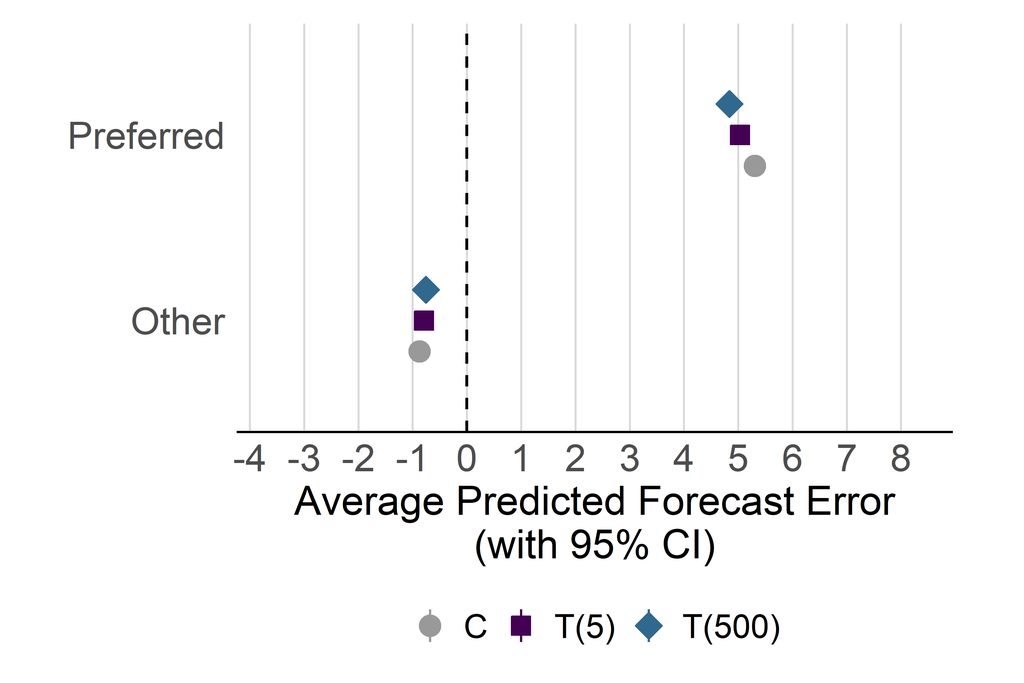

```r
plot_pref_vi_federal <- plot_wishful_thinking_pred(vi_federal$pred, "preferred_party_vi_dummy", # helper
  election = "federal",
  y_limits = c(-4, 8), y_breaks = seq(-4, 8, by = 1)
)
plot_pref_vi_federal
```

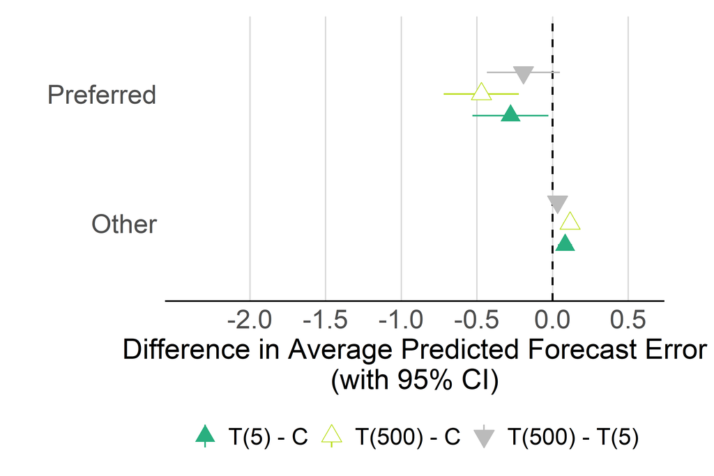

```r
save_figure(plot_pref_vi_federal, "figure_C4a_h3_vi_federal",
  election = "federal", # helper
  width = "subfigure", aspect = 1 / 2
)

plot_pref_vi_fd_federal <- plot_wishful_thinking_diff(vi_federal$diff, "preferred_party_vi_dummy", # helper
  election = "federal",
  y_limits = c(-2.5, 0.5),
  y_breaks = seq(-2, 0.5, by = 0.5)
)
plot_pref_vi_fd_federal
```

```r
save_figure(plot_pref_vi_fd_federal, "figure_C4b_h3_vi_fd_federal",
  election = "federal", # helper
  width = "subfigure", aspect = 1 / 2
)
```

```r
print_values(vi_federal$diff, c("diff", "preferred_party_vi_dummy", est_cols)) # helper
```

```
          diff preferred_party_vi_dummy estimate conf.low conf.high
      T(5) - C                        0     0.08     0.04      0.13
    T(500) - C                        0     0.12     0.07      0.16
 T(500) - T(5)                        0     0.03    -0.01      0.08
      T(5) - C                        1    -0.28    -0.53     -0.03
    T(500) - C                        1    -0.47    -0.72     -0.22
 T(500) - T(5)                        1    -0.19    -0.43      0.05
```

## Model 3d: Party Identification (Figure C.5)

```r
m_pref_pid_federal <- lm(list_votes_exp_diff ~ treatment * preferred_party_pid_dummy + lead_time + party,
  data = data_federal_pid_main
)
lmtest::coeftest(m_pref_pid_federal, vcov = sandwich::vcovCL(m_pref_pid_federal, cluster = ~ResponseId))
```

```
t test of coefficients:

                                                   Estimate Std. Error t value Pr(>|t|)
(Intercept)                                         -0.4146     0.1028   -4.03  5.5e-05 ***
treatmentTreatment (5)                               0.1117     0.0358    3.12   0.0018 **
treatmentTreatment (500)                             0.1513     0.0356    4.25  2.1e-05 ***
preferred_party_pid_dummy                            5.8154     0.1633   35.60  < 2e-16 ***
lead_time11                                         -0.0951     0.0833   -1.14   0.2533
lead_time12                                         -0.0923     0.0791   -1.17   0.2432
lead_time13                                         -0.0805     0.0920   -0.87   0.3817
lead_time14                                         -0.1824     0.1069   -1.71   0.0881 .
lead_time15                                         -0.0414     0.0915   -0.45   0.6509
lead_time16                                         -0.0830     0.0822   -1.01   0.3127
lead_time17                                         -0.0728     0.0726   -1.00   0.3161
lead_time18                                         -0.0640     0.0678   -0.94   0.3451
lead_time19                                         -0.0503     0.0678   -0.74   0.4582
lead_time20                                         -0.0529     0.0689   -0.77   0.4427
lead_time21                                         -0.0644     0.0834   -0.77   0.4397
lead_time22                                         -0.1580     0.0809   -1.95   0.0508 .
lead_time23                                         -0.0363     0.0699   -0.52   0.6031
lead_time25                                         -0.0895     0.0808   -1.11   0.2680
lead_time26                                         -0.1629     0.1137   -1.43   0.1519
lead_time29                                         -0.0882     0.0879   -1.00   0.3153
lead_time30                                         -0.0226     0.0788   -0.29   0.7746
partyBSW                                             1.7635     0.0941   18.74  < 2e-16 ***
partyCDU/CSU                                        -2.2499     0.1052  -21.38  < 2e-16 ***
partyFDP                                             1.4624     0.0986   14.84  < 2e-16 ***
partyGreens                                          0.2118     0.1062    1.99   0.0462 *
partyLeft                                           -3.5583     0.0961  -37.02  < 2e-16 ***
partySPD                                            -0.2752     0.1134   -2.43   0.0152 *
treatmentTreatment (5):preferred_party_pid_dummy    -0.4981     0.2178   -2.29   0.0222 *
treatmentTreatment (500):preferred_party_pid_dummy  -0.6344     0.2188   -2.90   0.0037 **
---
Signif. codes:  0 '***' 0.001 '**' 0.01 '*' 0.05 '.' 0.1 ' ' 1
```

```r
count_model_n(m_pref_pid_federal, data_federal_pid_main) # helper
```

```
# A tibble: 1 × 2
  respondents observations
        <int>        <int>
1       10499        73493
```

```r
pid_federal <- compute_treatment_effects(m_pref_pid_federal, data_federal_pid_main, # helper
  by = "preferred_party_pid_dummy", vcov = ~ResponseId
)
```

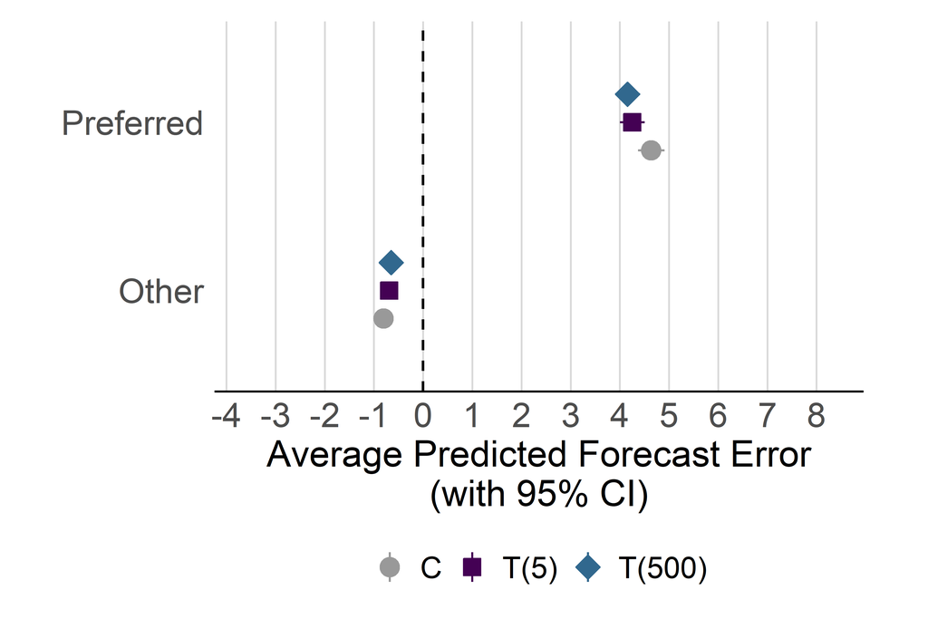

```r
plot_pref_pid_federal <- plot_wishful_thinking_pred(pid_federal$pred, "preferred_party_pid_dummy", # helper
  election = "federal",
  y_limits = c(-4, 8), y_breaks = seq(-4, 8, by = 1)
)
plot_pref_pid_federal
```

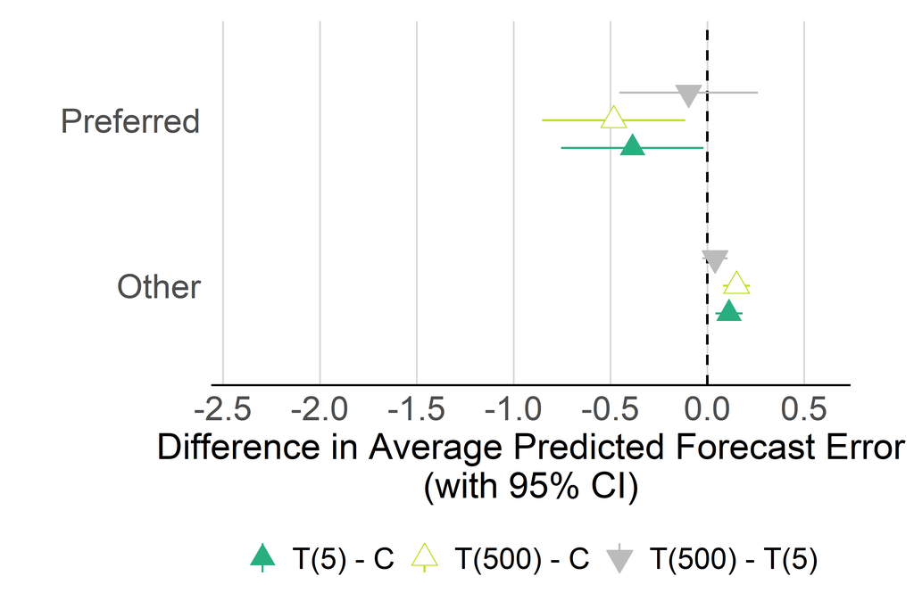

```r
save_figure(plot_pref_pid_federal, "figure_C5a_h3_pid_federal",
  election = "federal", # helper
  width = "subfigure", aspect = 1 / 2
)

plot_pref_pid_fd_federal <- plot_wishful_thinking_diff(pid_federal$diff, "preferred_party_pid_dummy", # helper
  election = "federal",
  y_limits = c(-2.5, 0.5),
  y_breaks = seq(-2.5, 0.5, by = 0.5)
)
plot_pref_pid_fd_federal
```

```r
save_figure(plot_pref_pid_fd_federal, "figure_C5b_h3_pid_fd_federal",
  election = "federal", # helper
  width = "subfigure", aspect = 1 / 2
)
```

```r
print_values(pid_federal$diff, c("diff", "preferred_party_pid_dummy", est_cols)) # helper
```

```
          diff preferred_party_pid_dummy estimate conf.low conf.high
      T(5) - C                         0     0.11     0.04      0.18
    T(500) - C                         0     0.15     0.08      0.22
 T(500) - T(5)                         0     0.04    -0.03      0.11
      T(5) - C                         1    -0.39    -0.75     -0.02
    T(500) - C                         1    -0.48    -0.85     -0.11
 T(500) - T(5)                         1    -0.10    -0.45      0.26
```

## Model 3e: PTV Score (Figure C.6)

Forecast error on treatment interacted with the PTV score (1-11) of each party.

```r
m_pref_ptv_score_federal <- lm(list_votes_exp_diff ~ treatment * ptv_score + lead_time + party,
  data = data_federal_ptvscore_main
)
lmtest::coeftest(m_pref_ptv_score_federal, vcov = sandwich::vcovCL(m_pref_ptv_score_federal, cluster = ~ResponseId))
```

```
t test of coefficients:

                                   Estimate Std. Error t value Pr(>|t|)
(Intercept)                        -2.61213    0.13677  -19.10  < 2e-16 ***
treatmentTreatment (5)              0.26017    0.06083    4.28  1.9e-05 ***
treatmentTreatment (500)            0.33140    0.06088    5.44  5.2e-08 ***
ptv_score                           0.77000    0.01131   68.08  < 2e-16 ***
lead_time3                          0.06456    0.12522    0.52  0.60618
lead_time4                          0.09499    0.12213    0.78  0.43671
lead_time5                          0.05409    0.12270    0.44  0.65932
lead_time10                         0.19234    0.14622    1.32  0.18838
lead_time11                         0.00482    0.13642    0.04  0.97184
lead_time12                         0.20740    0.13172    1.57  0.11537
lead_time13                         0.16175    0.13093    1.24  0.21670
lead_time14                         0.09033    0.12855    0.70  0.48225
lead_time15                         0.08682    0.12861    0.68  0.49964
lead_time16                         0.09544    0.12558    0.76  0.44727
lead_time17                         0.17562    0.12303    1.43  0.15343
lead_time18                         0.18013    0.12173    1.48  0.13896
lead_time19                         0.19468    0.12178    1.60  0.10992
lead_time20                         0.15461    0.12266    1.26  0.20752
lead_time21                         0.03215    0.13412    0.24  0.81055
lead_time22                         0.01782    0.13161    0.14  0.89230
lead_time23                         0.06626    0.12403    0.53  0.59319
lead_time25                         0.23867    0.13379    1.78  0.07444 .
lead_time26                         0.10352    0.16081    0.64  0.51972
lead_time29                         0.32385    0.14986    2.16  0.03070 *
lead_time30                         0.40457    0.13431    3.01  0.00259 **
partyBSW                            1.31714    0.05788   22.76  < 2e-16 ***
partyCDU/CSU                       -3.22522    0.06760  -47.71  < 2e-16 ***
partyFDP                            1.24735    0.05950   20.96  < 2e-16 ***
partyGreens                        -0.24163    0.06376   -3.79  0.00015 ***
partyLeft                          -3.10170    0.06106  -50.80  < 2e-16 ***
partySPD                           -1.03213    0.06933  -14.89  < 2e-16 ***
treatmentTreatment (5):ptv_score   -0.05483    0.01477   -3.71  0.00020 ***
treatmentTreatment (500):ptv_score -0.06689    0.01481   -4.52  6.3e-06 ***
---
Signif. codes:  0 '***' 0.001 '**' 0.01 '*' 0.05 '.' 0.1 ' ' 1
```

```r
count_model_n(m_pref_ptv_score_federal, data_federal_ptvscore_main) # helper
```

```
# A tibble: 1 × 2
  respondents observations
        <int>        <int>
1       28410       197547
```

```r
ptv_score_federal <- compute_treatment_effects(m_pref_ptv_score_federal, data_federal_ptvscore_main, # helper
  by = "ptv_score", vcov = ~ResponseId
)
ptv_score_federal$pred <- ptv_score_federal$pred %>%
  mutate(treatment = recode_groups_federal(treatment)) # helper
```

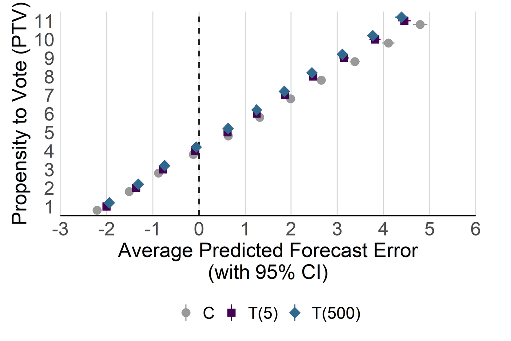

```r
plot_ptv_score_federal <- plot_ptv_score(ptv_score_federal$pred, election = "federal") # helper
plot_ptv_score_federal
```

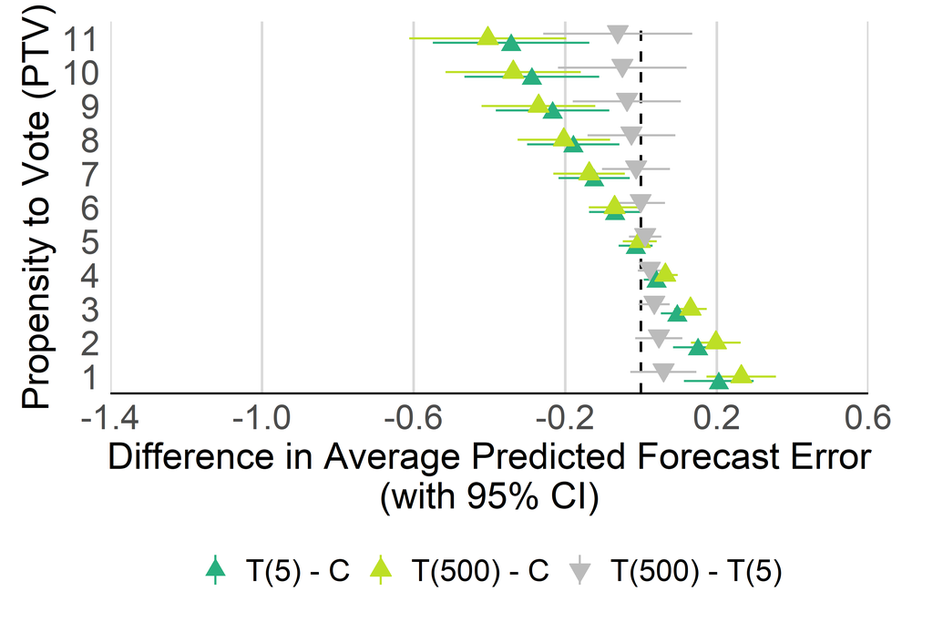

```r
save_figure(plot_ptv_score_federal, "figure_C6a_h3_ptvscore_federal",
  election = "federal", # helper
  width = "subfigure", aspect = 8 / 9
)

plot_ptv_score_fd_federal <- plot_ptv_score(ptv_score_federal$diff, election = "federal", diff = TRUE) # helper
plot_ptv_score_fd_federal
```

```r
save_figure(plot_ptv_score_fd_federal, "figure_C6b_h3_ptvscore_fd_federal",
  election = "federal", # helper
  width = "subfigure", aspect = 8 / 9
)
```

Values at PTV 1 and 11 (paper section Results, robustness checks).

```r
ptv_score_federal$pred %>%
  filter(ptv_score %in% c(1, 11)) %>%
  print_values(c("treatment", "ptv_score", est_cols)) # helper
```

```
 treatment ptv_score estimate conf.low conf.high
         C         1    -2.21    -2.28     -2.14
         C        11     4.80     4.64      4.95
      T(5)         1    -2.00    -2.06     -1.94
      T(5)        11     4.45     4.31      4.59
    T(500)         1    -1.94    -2.01     -1.88
    T(500)        11     4.39     4.25      4.53
```

```r
ptv_score_federal$diff %>%
  filter(ptv_score %in% c(1, 11)) %>%
  print_values(c("diff", "ptv_score", est_cols)) # helper
```

```
          diff ptv_score estimate conf.low conf.high
      T(5) - C         1     0.21     0.11      0.30
    T(500) - C         1     0.26     0.17      0.36
 T(500) - T(5)         1     0.06    -0.03      0.15
      T(5) - C        11    -0.34    -0.55     -0.14
    T(500) - C        11    -0.40    -0.61     -0.20
 T(500) - T(5)        11    -0.06    -0.26      0.14
```

Lowest PTV score with a positive forecast error, by group.

```r
ptv_score_federal$pred %>%
  filter(estimate > 0) %>%
  group_by(treatment) %>%
  summarize(first_positive_score = min(ptv_score))
```

```
# A tibble: 3 × 2
  treatment first_positive_score
  <fct>                    <dbl>
1 C                            5
2 T(5)                         5
3 T(500)                       5
```

## Heterogeneity by Education (Figure C.11)

Forecast error on treatment interacted with the preferred-party dummy (PTV) and educational attainment.

```r
data_federal_ptv_educ_main <- data_federal_ptv_main %>%
  left_join(data_federal_main %>% select(ResponseId, education_eng), by = "ResponseId") %>%
  filter(!is.na(education_eng), education_eng != "Still in School") %>%
  mutate(education_eng = droplevels(factor(education_eng, levels = c("Low", "Medium", "High"))))

m_pref_ptv_educ_federal <- lm(
  list_votes_exp_diff ~ treatment * preferred_party_ptv_dummy * education_eng + lead_time + party,
  data = data_federal_ptv_educ_main
)
count_model_n(m_pref_ptv_educ_federal, data_federal_ptv_educ_main) # helper
```

```
# A tibble: 1 × 2
  respondents observations
        <int>        <int>
1       22661       157556
```

```r
ptv_educ_federal <- compute_treatment_effects(m_pref_ptv_educ_federal, data_federal_ptv_educ_main, # helper
  by = c("preferred_party_ptv_dummy", "education_eng"), vcov = ~ResponseId
)
ptv_educ_federal$pred <- ptv_educ_federal$pred %>%
  mutate(
    treatment = factor_groups_federal(treatment), # helper
    preferred_party_ptv_dummy = factor(preferred_party_ptv_dummy, labels = pref_label)
  )
ptv_educ_federal$diff <- ptv_educ_federal$diff %>%
  mutate(
    education_eng = factor(education_eng, levels = c("Low", "Medium", "High")),
    preferred_party_ptv_dummy = factor(preferred_party_ptv_dummy, labels = pref_label)
  )
```

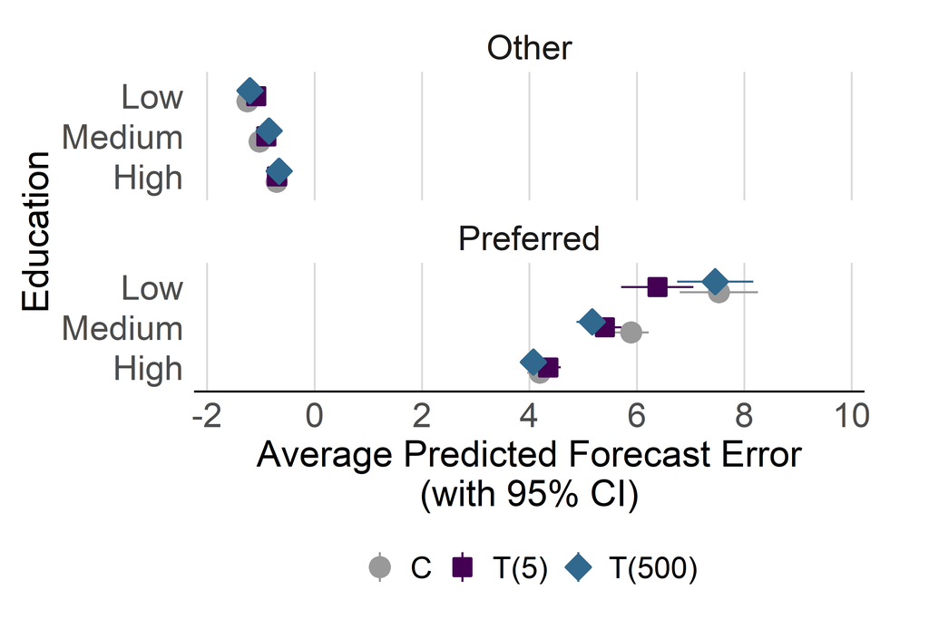

```r
plot_ptv_educ_federal <- plot_by_moderator( # helper
  ptv_educ_federal$pred, "education_eng", "Education", "Average Predicted Forecast Error\n(with 95% CI)",
  election = "federal", facet = TRUE, reverse_x = TRUE
)
plot_ptv_educ_federal
```

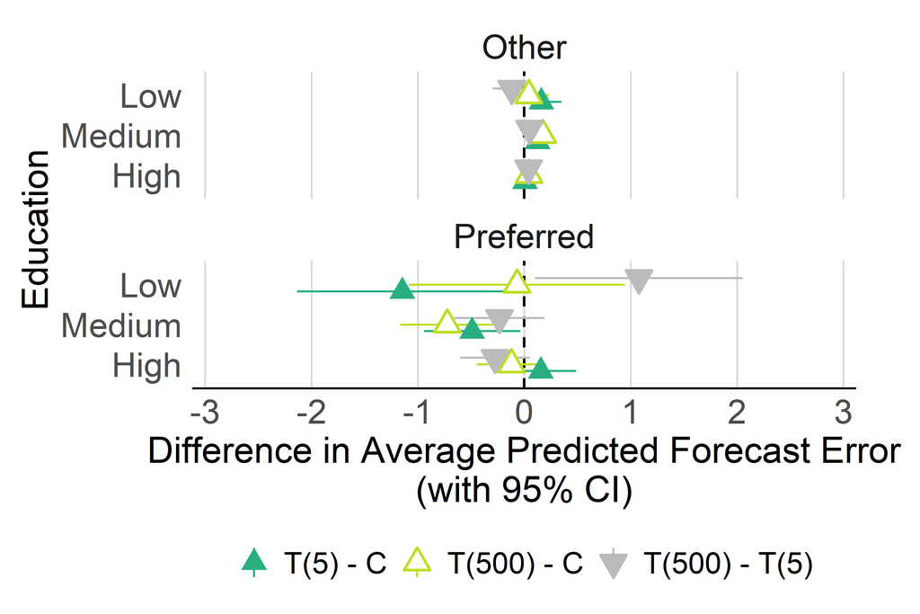

```r
save_figure(plot_ptv_educ_federal, "figure_C11a_h3_ptv_educ_federal",
  election = "federal", # helper
  width = "subfigure", aspect = 6 / 8
)

plot_ptv_educ_fd_federal <- plot_by_moderator( # helper
  ptv_educ_federal$diff, "education_eng", "Education", "Difference in Average Predicted Forecast Error\n(with 95% CI)",
  election = "federal", diff = TRUE, facet = TRUE, reverse_x = TRUE
)
plot_ptv_educ_fd_federal
```

```r
save_figure(plot_ptv_educ_fd_federal, "figure_C11b_h3_ptv_educ_fd_federal",
  election = "federal", # helper
  width = "subfigure", aspect = 6 / 8
)
```

```r
print_values(ptv_educ_federal$diff, c("preferred_party_ptv_dummy", "education_eng", "diff", est_cols)) # helper
```

```
 preferred_party_ptv_dummy education_eng          diff estimate conf.low conf.high
                     Other           Low      T(5) - C     0.16    -0.03      0.35
                     Other           Low    T(500) - C     0.04    -0.15      0.23
                     Other           Low T(500) - T(5)    -0.12    -0.30      0.06
                     Other        Medium      T(5) - C     0.12     0.04      0.21
                     Other        Medium    T(500) - C     0.17     0.09      0.26
                     Other        Medium T(500) - T(5)     0.05    -0.03      0.13
                     Other          High      T(5) - C     0.01    -0.05      0.07
                     Other          High    T(500) - C     0.05    -0.01      0.11
                     Other          High T(500) - T(5)     0.04    -0.02      0.10
                 Preferred           Low      T(5) - C    -1.15    -2.14     -0.15
                 Preferred           Low    T(500) - C    -0.07    -1.08      0.95
                 Preferred           Low T(500) - T(5)     1.08     0.10      2.05
                 Preferred        Medium      T(5) - C    -0.49    -0.94     -0.04
                 Preferred        Medium    T(500) - C    -0.72    -1.17     -0.28
                 Preferred        Medium T(500) - T(5)    -0.23    -0.66      0.19
                 Preferred          High      T(5) - C     0.15    -0.18      0.49
                 Preferred          High    T(500) - C    -0.12    -0.45      0.21
                 Preferred          High T(500) - T(5)    -0.28    -0.60      0.05
```

## Heterogeneity by Political Interest (Figure C.12)

```r
data_federal_ptv_polint_main <- data_federal_ptv_main %>%
  left_join(data_federal_main %>% select(ResponseId, pol_interest), by = "ResponseId") %>%
  filter(!is.na(pol_interest)) %>%
  mutate(pol_interest = recode_pol_interest(pol_interest, pol_interest_levels_federal)) # helper

m_pref_ptv_polint_federal <- lm(
  list_votes_exp_diff ~ treatment * preferred_party_ptv_dummy * pol_interest + lead_time + party,
  data = data_federal_ptv_polint_main
)
count_model_n(m_pref_ptv_polint_federal, data_federal_ptv_polint_main) # helper
```

```
# A tibble: 1 × 2
  respondents observations
        <int>        <int>
1       23044       160208
```

```r
ptv_polint_federal <- compute_treatment_effects(m_pref_ptv_polint_federal, data_federal_ptv_polint_main, # helper
  by = c("preferred_party_ptv_dummy", "pol_interest"), vcov = ~ResponseId
)
ptv_polint_federal$pred <- ptv_polint_federal$pred %>%
  mutate(
    treatment = factor_groups_federal(treatment), # helper
    preferred_party_ptv_dummy = factor(preferred_party_ptv_dummy, labels = pref_label)
  )
ptv_polint_federal$diff <- ptv_polint_federal$diff %>%
  mutate(
    pol_interest = factor(pol_interest, levels = levels(data_federal_ptv_polint_main$pol_interest)),
    preferred_party_ptv_dummy = factor(preferred_party_ptv_dummy, labels = pref_label)
  )
```

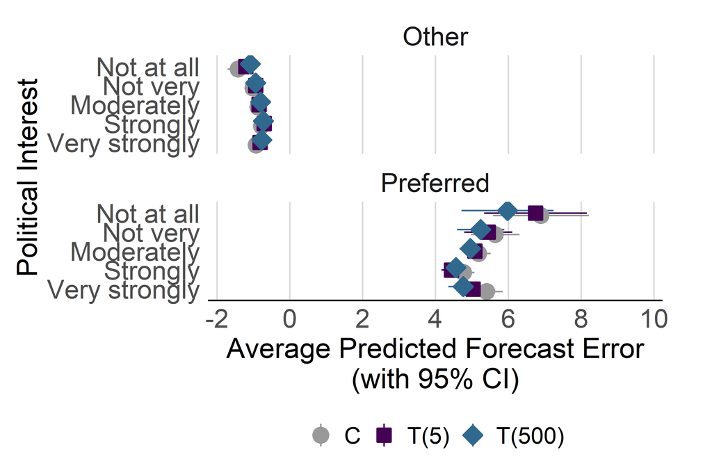

```r
plot_ptv_polint_federal <- plot_by_moderator( # helper
  ptv_polint_federal$pred, "pol_interest", "Political Interest", "Average Predicted Forecast Error\n(with 95% CI)",
  election = "federal", facet = TRUE
)
plot_ptv_polint_federal
```

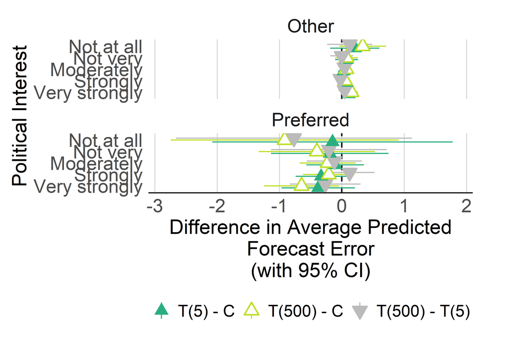

```r
save_figure(plot_ptv_polint_federal, "figure_C12a_h3_ptv_polint_federal",
  election = "federal", # helper
  width = "subfigure", aspect = 8 / 8
)

plot_ptv_polint_fd_federal <- plot_by_moderator( # helper
  ptv_polint_federal$diff, "pol_interest", "Political Interest", "Difference in Average Predicted\nForecast Error\n(with 95% CI)",
  election = "federal", diff = TRUE, facet = TRUE
)
plot_ptv_polint_fd_federal
```

```r
save_figure(plot_ptv_polint_fd_federal, "figure_C12b_h3_ptv_polint_fd_federal",
  election = "federal", # helper
  width = "subfigure", aspect = 8 / 8
)
```

```r
print_values(ptv_polint_federal$diff, c("preferred_party_ptv_dummy", "pol_interest", "diff", est_cols)) # helper
```

```
 preferred_party_ptv_dummy  pol_interest          diff estimate conf.low conf.high
                     Other Very strongly      T(5) - C     0.11     0.00      0.22
                     Other Very strongly    T(500) - C     0.15     0.05      0.26
                     Other Very strongly T(500) - T(5)     0.05    -0.06      0.15
                     Other      Strongly      T(5) - C     0.07     0.00      0.15
                     Other      Strongly    T(500) - C     0.05    -0.02      0.13
                     Other      Strongly T(500) - T(5)    -0.02    -0.09      0.05
                     Other    Moderately      T(5) - C     0.03    -0.06      0.11
                     Other    Moderately    T(500) - C     0.07    -0.01      0.16
                     Other    Moderately T(500) - T(5)     0.04    -0.04      0.13
                     Other      Not very      T(5) - C     0.08    -0.11      0.26
                     Other      Not very    T(500) - C     0.07    -0.11      0.26
                     Other      Not very T(500) - T(5)     0.00    -0.19      0.18
                     Other    Not at all      T(5) - C     0.21    -0.19      0.60
                     Other    Not at all    T(500) - C     0.33    -0.04      0.71
                     Other    Not at all T(500) - T(5)     0.13    -0.24      0.49
                 Preferred Very strongly      T(5) - C    -0.38    -0.97      0.21
                 Preferred Very strongly    T(500) - C    -0.65    -1.25     -0.04
                 Preferred Very strongly T(500) - T(5)    -0.27    -0.83      0.30
                 Preferred      Strongly      T(5) - C    -0.33    -0.74      0.07
                 Preferred      Strongly    T(500) - C    -0.21    -0.62      0.21
                 Preferred      Strongly T(500) - T(5)     0.12    -0.27      0.52
                 Preferred    Moderately      T(5) - C    -0.11    -0.57      0.36
                 Preferred    Moderately    T(500) - C    -0.23    -0.68      0.22
                 Preferred    Moderately T(500) - T(5)    -0.12    -0.56      0.32
                 Preferred      Not very      T(5) - C    -0.19    -1.13      0.75
                 Preferred      Not very    T(500) - C    -0.40    -1.33      0.53
                 Preferred      Not very T(500) - T(5)    -0.21    -1.13      0.72
                 Preferred    Not at all      T(5) - C    -0.15    -2.08      1.78
                 Preferred    Not at all    T(500) - C    -0.92    -2.74      0.91
                 Preferred    Not at all T(500) - T(5)    -0.77    -2.66      1.13
```

# Regression Table (Table C.1)

```r
model_list_federal <- list(
  m_time_full_federal,
  m_mae_full_federal,
  m_rmse_full_federal,
  m_pref_ptv_federal,
  m_pref_ptv_ties_federal,
  m_pref_vi_federal,
  m_pref_pid_federal,
  m_pref_ptv_score_federal
)

write_models_table( # helper
  models      = model_list_federal,
  header      = header_models,
  model_names = labels_models,
  groups      = groups_models,
  coef_map    = coef_map_federal,
  cluster_idx = 4:8,
  caption     = "Linear Regression Models for the Federal Election",
  label       = "tab:models_federal",
  note        = note_models,
  file        = "output/tables/table_C1_models_federal.tex"
)
```

# Robustness: Without Excluding Satisficers

## Who Was Excluded (Table C.3)

Share excluded by experimental group (paper section Data).

```r
data_federal_noexcl %>%
  transmute(treatment = as.character(treatment), excluded) %>%
  bind_rows(mutate(., treatment = "All")) %>%
  group_by(treatment) %>%
  summarize(n = n(), n_excluded = sum(excluded), share_excluded = mean(excluded), .groups = "drop") %>%
  print_values(digits = 4) # helper
```

```
       treatment     n n_excluded share_excluded
             All 29195        765         0.0262
         Control  9697        297         0.0306
   Treatment (5)  9728        253         0.0260
 Treatment (500)  9770        215         0.0220
```

```r
m_excl_logit_federal_demo <- glm(
  excluded ~ treatment + age_group + gender_eng2 + education_eng + turnout_int_dummy + bula_en,
  family = binomial,
  data = data_federal_noexcl
)
summary(m_excl_logit_federal_demo)
```

```
Call:
glm(formula = excluded ~ treatment + age_group + gender_eng2 +
    education_eng + turnout_int_dummy + bula_en, family = binomial,
    data = data_federal_noexcl)

Coefficients:
                                     Estimate Std. Error z value Pr(>|z|)
(Intercept)                          -1.76966    0.17528  -10.10  < 2e-16 ***
treatmentTreatment (5)               -0.18143    0.08994   -2.02  0.04367 *
treatmentTreatment (500)             -0.34275    0.09373   -3.66  0.00026 ***
age_group30-39                        0.08222    0.12260    0.67  0.50246
age_group40-49                        0.03222    0.12317    0.26  0.79365
age_group50-59                       -0.49551    0.13447   -3.69  0.00023 ***
age_group60+                         -0.95266    0.14283   -6.67  2.6e-11 ***
gender_eng2Women                     -0.08149    0.07681   -1.06  0.28869
education_engMedium                  -0.80932    0.09996   -8.10  5.7e-16 ***
education_engHigh                    -1.43540    0.10312  -13.92  < 2e-16 ***
education_engStill in School         -0.96375    0.43211   -2.23  0.02573 *
turnout_int_dummyja                  -0.63943    0.08248   -7.75  9.0e-15 ***
bula_enBavaria                       -0.14617    0.15246   -0.96  0.33767
bula_enBerlin                         0.16561    0.19211    0.86  0.38866
bula_enBrandenburg                    0.11577    0.24173    0.48  0.63200
bula_enBremen                         0.40559    0.36266    1.12  0.26341
bula_enHamburg                       -0.12502    0.26579   -0.47  0.63808
bula_enHesse                          0.03750    0.17774    0.21  0.83289
bula_enLower Saxony                   0.01131    0.17024    0.07  0.94703
bula_enMecklenburg-Western Pomerania  0.59028    0.23385    2.52  0.01160 *
bula_enNorth Rhine-Westphalia         0.03374    0.14187    0.24  0.81200
bula_enRhineland-Palatinate          -0.00313    0.20680   -0.02  0.98792
bula_enSaarland                      -0.39872    0.42924   -0.93  0.35293
bula_enSaxony                        -0.00718    0.18918   -0.04  0.96973
bula_enSaxony-Anhalt                  0.30933    0.21985    1.41  0.15943
bula_enSchleswig-Holstein            -0.18557    0.24083   -0.77  0.44099
bula_enThuringia                     -0.10124    0.26023   -0.39  0.69724
---
Signif. codes:  0 '***' 0.001 '**' 0.01 '*' 0.05 '.' 0.1 ' ' 1

(Dispersion parameter for binomial family taken to be 1)

    Null deviance: 6775.7  on 28617  degrees of freedom
Residual deviance: 6405.3  on 28591  degrees of freedom
  (577 Beobachtungen als fehlend gelöscht)
AIC: 6459

Number of Fisher Scoring iterations: 7
```

```r
# Row labels and reference categories from the model
# State dummies as one fixed-effects row instead of one row per state
coef_names_excl_federal <- names(coef(m_excl_logit_federal_demo)) %>%
  str_subset("^bula_en", negate = TRUE)
coef_map_excl_federal <- coef_names_excl_federal %>%
  str_replace("^\\(Intercept\\)$", "Intercept") %>%
  str_replace("^treatmentTreatment \\(5\\)$", "T(5)") %>%
  str_replace("^treatmentTreatment \\(500\\)$", "T(500)") %>%
  str_replace("^age_group", "Age ") %>%
  str_replace("^gender_eng2", "Gender: ") %>%
  str_replace("^education_eng", "Education: ") %>%
  str_replace("^turnout_int_dummyja$", "Intends to Vote") %>%
  as.list() %>%
  set_names(coef_names_excl_federal)
ref_excl_federal <- m_excl_logit_federal_demo$xlevels

note_excl_logit_federal <- paste0(
  "Note: * p < 0.05, ** p < 0.01, *** p < 0.001. Logistic regression of being excluded ",
  "(answered 50\\% for two parties) on treatment and respondent characteristics. ",
  "Reference categories: Control group, age ", ref_excl_federal$age_group[1],
  ", gender ", ref_excl_federal$gender_eng2[1], " (incl. diverse), education ",
  ref_excl_federal$education_eng[1], ", no turnout intention, state ", ref_excl_federal$bula_en[1], ". ",
  "The model includes fixed effects for the ", length(ref_excl_federal$bula_en), " federal states, ",
  "whose coefficients are not shown."
)

write_logit_table( # helper
  m_excl_logit_federal_demo,
  coef_map = coef_map_excl_federal,
  fe       = c("State Fixed Effects" = "bula_en"),
  caption  = "Logistic Regression of Being Excluded (Answered 50\\% Twice) on Treatment and Respondent Characteristics (Federal)",
  label    = "tab:excl_logit_federal",
  note     = note_excl_logit_federal,
  file     = "output/tables/table_C3_exclusions_logit_federal.tex"
)
```

## Models Without Exclusions (Table C.5)

All main models re-estimated on all first-time respondents. The response time model still drops latency outliers (mean + 2 SD, computed in this sample).

```r
data_federal_time_noexcl_nooutliers <- data_federal_time_noexcl %>%
  filter(t_list_votes_exp_Page_Submit <= compute_time_cutoff(t_list_votes_exp_Page_Submit)) # helper

m_time_full_federal_noexcl <- lm(t_list_votes_exp_Page_Submit_log ~ treatment + baseline_speed + duration + lead_time,
  data = data_federal_time_noexcl_nooutliers
)
m_mae_full_federal_noexcl <- lm(list_votes_exp_mae ~ treatment + lead_time, data = data_federal_noexcl)
m_rmse_full_federal_noexcl <- lm(list_votes_exp_rmse ~ treatment + lead_time, data = data_federal_noexcl)
m_pref_ptv_federal_noexcl <- lm(list_votes_exp_diff ~ treatment * preferred_party_ptv_dummy + lead_time + party,
  data = data_federal_ptv_noexcl
)
m_pref_ptv_ties_federal_noexcl <- lm(list_votes_exp_diff ~ treatment * preferred_party_ptv_dummy_ties + lead_time + party,
  data = data_federal_ptvties_noexcl
)
m_pref_vi_federal_noexcl <- lm(list_votes_exp_diff ~ treatment * preferred_party_vi_dummy + lead_time + party,
  data = data_federal_vi_noexcl
)
m_pref_pid_federal_noexcl <- lm(list_votes_exp_diff ~ treatment * preferred_party_pid_dummy + lead_time + party,
  data = data_federal_pid_noexcl
)
m_pref_ptv_score_federal_noexcl <- lm(list_votes_exp_diff ~ treatment * ptv_score + lead_time + party,
  data = data_federal_ptvscore_noexcl
)

write_models_table( # helper
  models = list(
    m_time_full_federal_noexcl, m_mae_full_federal_noexcl, m_rmse_full_federal_noexcl,
    m_pref_ptv_federal_noexcl, m_pref_ptv_ties_federal_noexcl, m_pref_vi_federal_noexcl,
    m_pref_pid_federal_noexcl, m_pref_ptv_score_federal_noexcl
  ),
  header = header_models,
  model_names = labels_models,
  groups = groups_models,
  coef_map = coef_map_federal,
  cluster_idx = 4:8,
  caption = "Linear Regression Models for the Federal Election Without Exclusions",
  label = "tab:models_federal_noexcl",
  note = "Note: * p < 0.05, ** p < 0.01, *** p < 0.001. Same models as Table~\\ref{tab:models_federal}, but including those respondents who answered 50\\% twice.",
  file = "output/tables/table_C5_models_noexcl_federal.tex"
)
```

## Main Sample vs. No Exclusions (Figure C.7a)

H1 without exclusions, transformed to seconds as in Figure 2.

```r
set.seed(20250223)
m_time_full_federal_avg_case_sim_noexcl <- simloglm(m_time_full_federal_noexcl, scenario = list(
  treatment = c("Control", "Treatment (5)", "Treatment (500)"),
  baseline_speed = mean(data_federal_time_noexcl_nooutliers$baseline_speed),
  duration = mean(data_federal_time_noexcl_nooutliers$duration),
  lead_time = "15"
))
time_median_federal_noexcl <- compute_time_effects(m_time_full_federal_avg_case_sim_noexcl, "median", time_diffs_federal) # helper

treatments_federal <- c("Control", "Treatment (5)", "Treatment (500)")
noexcl_comparison_federal <- list(
  compute_sample_effects_time(
    m_time_full_federal_avg_case_sim, treatments_federal, # helper
    time_median_federal$diff, "Main", "H1: Response Time (s, median)"
  ),
  compute_sample_effects_time(
    m_time_full_federal_avg_case_sim_noexcl, treatments_federal, # helper
    time_median_federal_noexcl$diff, "No excl.", "H1: Response Time (s, median)"
  ),
  compute_sample_effects(m_mae_full_federal, data_federal_main, "Main", "H2: MAE"), # helper
  compute_sample_effects(m_mae_full_federal_noexcl, data_federal_noexcl, "No excl.", "H2: MAE"), # helper
  compute_sample_effects(m_pref_ptv_federal, data_federal_ptv_main, "Main", "H3: Forecast Error (PTV)", # helper
    by = "preferred_party_ptv_dummy", vcov = ~ResponseId
  ),
  compute_sample_effects(m_pref_ptv_federal_noexcl, data_federal_ptv_noexcl, "No excl.", "H3: Forecast Error (PTV)", # helper
    by = "preferred_party_ptv_dummy", vcov = ~ResponseId
  )
)

fd_noexcl_federal <- map_dfr(noexcl_comparison_federal, "diff") %>%
  mutate(
    outcome = factor(outcome, levels = sample_outcome_levels)
  )
print_values(fd_noexcl_federal, c("outcome", "diff", "sample", est_cols)) # helper
```

```
                             outcome          diff   sample estimate conf.low conf.high
       H1: Response Time (s, median) T(500) - T(5)     Main     2.43     1.53      3.33
       H1: Response Time (s, median)      T(5) - C     Main     4.21     3.36      5.14
       H1: Response Time (s, median)    T(500) - C     Main     6.64     5.73      7.59
       H1: Response Time (s, median) T(500) - T(5) No excl.     2.65     1.71      3.58
       H1: Response Time (s, median)      T(5) - C No excl.     4.28     3.40      5.24
       H1: Response Time (s, median)    T(500) - C No excl.     6.93     5.98      7.93
                             H2: MAE      T(5) - C     Main    -0.23    -0.31     -0.15
                             H2: MAE    T(500) - C     Main    -0.32    -0.40     -0.24
                             H2: MAE T(500) - T(5)     Main    -0.09    -0.17     -0.01
                             H2: MAE      T(5) - C No excl.    -0.28    -0.38     -0.19
                             H2: MAE    T(500) - C No excl.    -0.43    -0.52     -0.33
                             H2: MAE T(500) - T(5) No excl.    -0.14    -0.24     -0.04
     H3: Forecast Error (PTV): Other      T(5) - C     Main     0.07     0.02      0.12
     H3: Forecast Error (PTV): Other    T(500) - C     Main     0.09     0.04      0.14
     H3: Forecast Error (PTV): Other T(500) - T(5)     Main     0.02    -0.03      0.06
 H3: Forecast Error (PTV): Preferred      T(5) - C     Main    -0.25    -0.51      0.01
 H3: Forecast Error (PTV): Preferred    T(500) - C     Main    -0.33    -0.59     -0.07
 H3: Forecast Error (PTV): Preferred T(500) - T(5)     Main    -0.08    -0.34      0.17
     H3: Forecast Error (PTV): Other      T(5) - C No excl.     0.09     0.03      0.15
     H3: Forecast Error (PTV): Other    T(500) - C No excl.     0.12     0.07      0.18
     H3: Forecast Error (PTV): Other T(500) - T(5) No excl.     0.04    -0.02      0.09
 H3: Forecast Error (PTV): Preferred      T(5) - C No excl.    -0.36    -0.64     -0.08
 H3: Forecast Error (PTV): Preferred    T(500) - C No excl.    -0.52    -0.80     -0.24
 H3: Forecast Error (PTV): Preferred T(500) - T(5) No excl.    -0.16    -0.43      0.11
```

```r
plot_noexcl_fd_federal <- plot_sample_diff(fd_noexcl_federal) # helper
plot_noexcl_fd_federal
```

[figure not shown]

```r
save_figure(plot_noexcl_fd_federal, "figure_C7a_h123_noexcl_fd_federal",
  election = "federal", # helper
  width = "full", aspect = 8 / 12
)
```